# simulation results analysis

João Gama

### Notes

The script to run the simulations is the following: /Users/jga039/Documents/simulations/final_data/all_simulations_steady_state_AND_time_to_extinction_REVIEW_commented.R

There are 3 types of output files:  
gama_parameters_….txt –> a dataframe of the combinations (conjugation, fitness, loss, facilitations, epistasis, etc) used as input for the simulations  
gama_steady_state_….txt –> a dataframe of the steady states of each of the combinations  
gama_time_to_extinction_…txt –> a dataframe of the time each entitity in combination takes to go extinct (conditions where the plasmid was maintained are obviously not included)

There are 4 files per type:  
..singles_expanded_all.. –> simulations where there’s only 1 type of interaction per combination (or no interaction at all)  
..singles_fixed_competitor.. –> simulations where there’s all possible interactions per combination, but the competitor plasmid is always the same.  
..solo.. –> simulations where there’s only 1 plasmid (includes controls of conjugation 10-10 and fitness >= 1)  
..solo_density –> control simulations where there’s only 1 plasmid and the initial density is 1e6 instead of 5e5

In this script I’ll analyse the data. This notebook is saved as /Users/jga039/Documents/simulations/full_simulation_analysis.Rmd along with the accompanying full_simulation_analysis.nb.html file.

#### System/Version details:

```r
R.version
```

```
               _
platform       x86_64-apple-darwin17.0
arch           x86_64
os             darwin17.0
system         x86_64, darwin17.0
status
major          4
minor          0.2
year           2020
month          06
day            22
svn rev        78730
language       R
version.string R version 4.0.2 (2020-06-22)
nickname       Taking Off Again
```

#### Loading required libraries:

```r
library('ggplot2'); library('patchwork'); library('ggthemes'); library('ggpubr') # for plotting
library('reshape2') # to restructure dataframes
library('pscl'); library('performance') # for R2 of logistic regression
library('FSA'); library('rcompanion') # kruskal post hoc tests
library('heplots') # for eta2
library('openxlsx') # writing to excel files
```

#### creating workbook for the supp tables (excel file):

```r
wb = createWorkbook()
```

# Analysing what happens when there is only one plasmid in the population.

#### Importing the simulation output files

```r
# steady state data ----
solo_steady_0 = read.table(file = '/Users/jga039/Documents/simulations/final_data/gama_steady_state_solo_REVIEW.txt') # reading the table for steady states
# the column ID has the following structure: "plasmid X":"plasmid Y"
# and each plasmid has the structure: "conjugation efficiency"_"intracellular_conjugation_effect"_"intercellular_conjugation_effect"_"fitness"_"epistastic_effect"_"loss"_"loss_interaction_effect"
# effect means the effect of the interaction on that plasmid; while "conjugation efficiency", "fitness" and "loss" are the innate values (before interaction)
## this format is the same for all data sets imported from here on...

# defining new columns (extracting info from column ID)
solo_steady_0['focal'] = apply(X = as.matrix(solo_steady_0$ID), MARGIN = 1, FUN = function(x){
  paste(unlist(strsplit(x = unlist(strsplit(x = as.character(x), split = ':'))[1], split = '_'))[c(1,4,6)], collapse = '_') } ) # extracting the ID of plasmid X (focal) as "conjugation efficiency"_"fitness"_"loss"

solo_steady_0['plasmid2'] = apply(X = as.matrix(solo_steady_0$ID), MARGIN = 1, FUN = function(x){
  paste(unlist(strsplit(x = unlist(strsplit(x = as.character(x), split = ':'))[2], split = '_'))[c(1,4,6)], collapse = '_') } ) # extracting the ID of plasmid Y (competitor) as "conjugation efficiency"_"fitness"_"loss"

solo_steady_0['loss'] = as.factor(apply(X = as.matrix(solo_steady_0$ID), MARGIN = 1, FUN = function(x){ unlist(strsplit(x = as.character(x), split = '_'))[12] } )) # further extracting focal's loss

solo_steady_0['fitness'] = as.factor(apply(X = as.matrix(solo_steady_0$focal), MARGIN = 1, FUN = function(x){ as.numeric(unlist(strsplit(x = as.character(x), split = '_'))[2]) } )) # further extracting focal's fitness

solo_steady_0['conjugation'] = as.factor(apply(X = as.matrix(solo_steady_0$focal), MARGIN = 1, FUN = function(x){ as.numeric(unlist(strsplit(x = as.character(x), split = '_'))[1]) } )) # further extracting focal's conjugation

ctrl_steady_0 = solo_steady_0[solo_steady_0$fitness %in% c('1','1.05') | solo_steady_0$conjugation == '1e-10',] # data set for controls of conjugation 10-10 and fitness >= 1
solo_steady_0 = solo_steady_0[!(solo_steady_0$fitness %in% c('1','1.05') | solo_steady_0$conjugation == '1e-10'),] # excluding these controls from the "main" data set
solo_steady_0$fitness = factor(solo_steady_0$fitness); solo_steady_0$conjugation = factor(solo_steady_0$conjugation) # recoding the 3 parameters as factors

# time to extinction data
solo_extinction = read.table(file = '/Users/jga039/Documents/simulations/final_data/gama_time_to_extinction_solo_REVIEW.txt') # reading the table for times to extinction
solo_extinction['focal'] = apply(X = as.matrix(solo_extinction$ID), MARGIN = 1, FUN = function(x){
  paste(unlist(strsplit(x = unlist(strsplit(x = as.character(x), split = ':'))[1], split = '_'))[c(1,4,6)], collapse = '_') } ) # extracting the ID of plasmid X (focal) as "conjugation efficiency"_"fitness"_"loss"
solo_extinction['plasmid2'] = apply(X = as.matrix(solo_extinction$ID), MARGIN = 1, FUN = function(x){
  paste(unlist(strsplit(x = unlist(strsplit(x = as.character(x), split = ':'))[2], split = '_'))[c(1,4,6)], collapse = '_') } ) # extracting the ID of plasmid Y (competitor) as "conjugation efficiency"_"fitness"_"loss"
solo_extinction['loss'] = as.factor(apply(X = as.matrix(solo_extinction$ID), MARGIN = 1, FUN = function(x){ unlist(strsplit(x = as.character(x), split = '_'))[12] } )) # further extracting focal's loss
solo_extinction['fitness'] = as.factor(apply(X = as.matrix(solo_extinction$focal), MARGIN = 1, FUN = function(x){ as.numeric(unlist(strsplit(x = as.character(x), split = '_'))[2]) } )) # further extracting focal's fitness
solo_extinction['conjugation'] = as.factor(apply(X = as.matrix(solo_extinction$focal), MARGIN = 1, FUN = function(x){ as.numeric(unlist(strsplit(x = as.character(x), split = '_'))[1]) } )) # further extracting focal's conjugation

ctrl_extinction = solo_extinction[solo_extinction$fitness %in% c('1','1.05') | solo_extinction$conjugation == '1e-10',] # data set for controls of conjugation 10-10 and fitness >= 1
solo_extinction = solo_extinction[!(solo_extinction$fitness %in% c('1','1.05') | solo_extinction$conjugation == '1e-10'),] # excluding these controls from the "main" data set
solo_extinction$fitness = factor(solo_extinction$fitness); solo_extinction$conjugation = factor(solo_extinction$conjugation) # recoding the 3 parameters as factors
```

### Overview of plasmid maintenance

```r
solo_steady = solo_steady_0[solo_steady_0$X >= 1, ] # subset of stable plasmids
print(paste('out of', nrow(solo_steady_0), 'plasmids', nrow(solo_steady), 'do not go to extinction'))
```

```
[1] "out of 36 plasmids 0 do not go to extinction"
```

### How is the time to extinction affected by the variable: fitness, conjugation, loss?

Apparently the plasmids always go extinct, but how does this vary between plasmids (ie different fitness, conjugation and loss rates)? Performing ANOVA (including interactions). All variables are numeric (not factors).

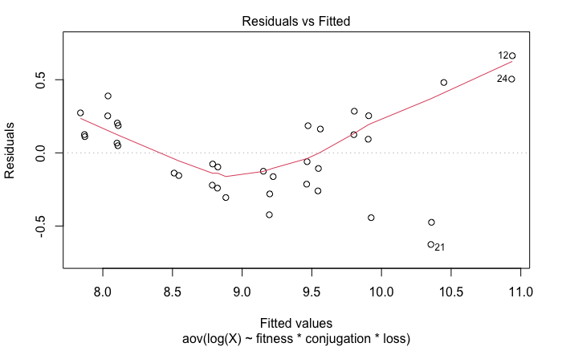

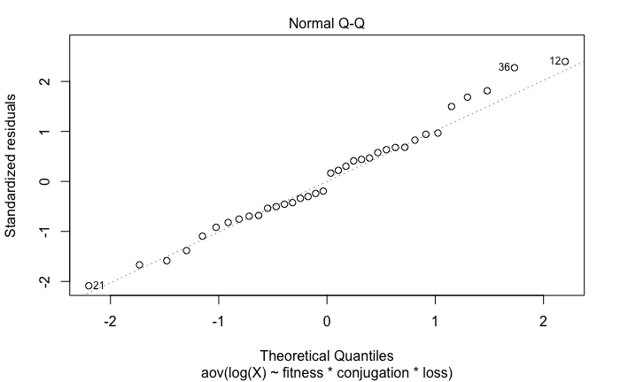

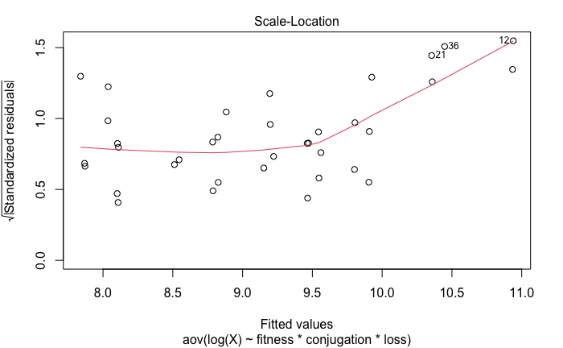

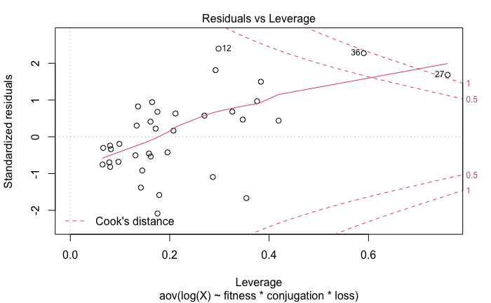

```r
tmp = solo_extinction; tmp$fitness = as.numeric(as.character(tmp$fitness)); tmp$conjugation = as.numeric(as.character(tmp$conjugation)); tmp$loss = as.numeric(as.character(tmp$loss)) # variables as numeric instead of factors
fit = aov(formula = log(X) ~ fitness * conjugation * loss, data = tmp) # performing the ANOVA
plot(fit) # ANOVA diagnostic plots below
```

Diagnostics:

Therefore, assumptions generally acceptable.

```r
# creating Supp.TableS1
Supp.TableS1 = cbind(data.frame(summary(fit)[[1]]),data.frame(etasq(fit, anova = F))); Supp.TableS1
```

```
                         Df       Sum.Sq      Mean.Sq      F.value       Pr..F. Partial.eta.2
fitness                   1 22.925665208 22.925665208 209.88960292 1.551389e-14   0.883045841
conjugation               1  2.365939215  2.365939215  21.66070375 7.137737e-05   0.436173919
loss                      1  0.789374314  0.789374314   7.22689876 1.195597e-02   0.207251882
fitness:conjugation       1  1.406291484  1.406291484  12.87491370 1.252502e-03   0.314983263
fitness:loss              1  0.032167848  0.032167848   0.29450386 5.916426e-01   0.010408518
conjugation:loss          1  0.007640809  0.007640809   0.06995331 7.933420e-01   0.002492107
fitness:conjugation:loss  1  0.009661713  0.009661713   0.08845515 7.683458e-01   0.003149164
Residuals                28  3.058363144  0.109227255           NA           NA            NA
```

```r
addWorksheet(wb, sheetName = "Supp.TableS1")
writeData(wb, sheet = 1, x = Supp.TableS1, startCol = 1, startRow = 1, colNames = T, rowNames = T, borders = 'all')
```

Time to extinction is affected by fitness, conjugation, loss and the interaction between fitness and conjugation.  
Plasmids persist more time with:

- increasing fitness
- increasing conjugation rates
- decreasing loss rates

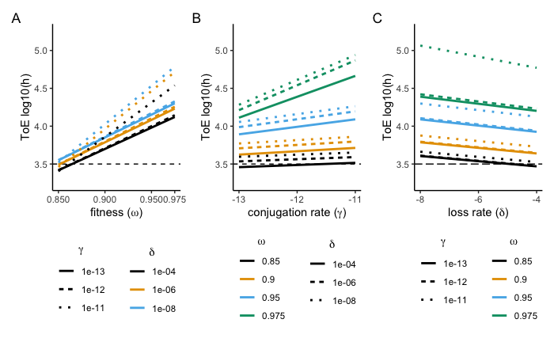

```r
my_palete = colorblind_pal()(4) # defining a color blind palete with 4 colors

# creating figure 1 panel A
tmp = solo_extinction; tmp$fitness = as.numeric(as.character(tmp$fitness))
tmp['conjugation loss'] = as.factor(apply(X = tmp, MARGIN = 1, FUN = function(x) {paste(as.character(x['conjugation']), as.character(x['loss']))}))
p1 = ggplot(data = tmp, mapping = aes(x = fitness, y = log10(X))) + theme_classic() + theme(legend.position = 'bottom', legend.direction = 'vertical') +
  geom_hline(yintercept = 3.5, linetype = 'dashed') + geom_smooth(method="lm", se = F, aes(linetype = conjugation, color = loss), show.legend = T, formula = y ~ x) +
  scale_linetype_manual(values = c('solid','22','13')) + scale_x_continuous(breaks = unique(tmp$fitness)) + ylim(3.25,5.25) + scale_color_manual(values = my_palete) +
  labs(tag = 'A', linetype = expression(gamma), color = expression(delta)) + ylab('ToE log10(h)') + xlab(expression(paste('fitness (',omega,')', sep = ''))) + theme(legend.title.align=0.5) + guides(linetype = guide_legend(override.aes = c(colour = 'black')))

# creating figure 1 panel B
tmp = solo_extinction; tmp$conjugation = as.numeric(as.character(tmp$conjugation))
tmp['fitness loss'] = as.factor(apply(X = tmp, MARGIN = 1, FUN = function(x) {paste(as.character(x['fitness']), as.character(x['loss']))}))
p2 = ggplot(data = tmp, mapping = aes(x = log10(conjugation), y = log10(X))) + theme_classic() + theme(legend.position = 'bottom', legend.direction = 'vertical') +
   geom_hline(yintercept = 3.5, linetype = 'dashed') + geom_smooth(method="lm", se = F, aes(linetype = loss, color = fitness), show.legend = T, formula = y ~ x) +
   scale_linetype_manual(values = c('solid','22','13')) + scale_x_continuous(breaks = log10(unique(tmp$conjugation))) + ylim(3.25,5.25) + scale_color_manual(values = my_palete) +
  labs(tag = 'B', linetype = expression(delta), color = expression(omega)) + ylab('ToE log10(h)') + xlab(expression(paste('conjugation rate (',gamma,')', sep = ''))) + theme(legend.title.align=0.5) + guides(linetype = guide_legend(override.aes = c(colour = 'black')))

# creating figure 1 panel C
tmp = solo_extinction; tmp$loss = as.numeric(as.character(tmp$loss))
tmp['fitness conjugation'] = as.factor(apply(X = tmp, MARGIN = 1, FUN = function(x) {paste(as.character(x['fitness']), as.character(x['conjugation']))}))
p3 = ggplot(data = tmp, mapping = aes(x = log10(loss), y = log10(X))) + theme_classic() + theme(legend.position = 'bottom', legend.direction = 'vertical') +
   geom_hline(yintercept = 3.5, linetype = 'longdash') + geom_smooth(method="lm", se = F, aes(linetype = conjugation, color = fitness), show.legend = T, formula = y ~ x) +
   scale_linetype_manual(values = c('solid','22','13')) + scale_x_continuous(breaks = log10(unique(tmp$loss))) + ylim(3.25,5.25) + scale_color_manual(values = my_palete) +
  labs(tag = 'C', linetype = expression(gamma), color = expression(omega)) + ylab('ToE log10(h)') + xlab(expression(paste('loss rate (',delta,')',sep = ''))) + theme(legend.title.align=0.5) + guides(linetype = guide_legend(override.aes = c(colour = 'black')))

# assembling and exporting figure 1
fig1 = p1 + p2 + p3; fig1
ggsave(plot = fig1, filename = '/Users/jga039/Documents/simulations/analysis/figures_tables/fig_01.tiff', width = 210, height = 148, units = 'mm', dpi = 300)
```

### Control density Simulation

To control for initial density effects, the starting density of the focal plasmid is 1e6 (instead of 5e5 cells) like when two plasmids are in the population.

#### Importing the simulation output files for the density control

```r
# control data
# importing and restructuring data as described before
solo_extinction_density = read.table(file = '/Users/jga039/Documents/simulations/final_data/gama_time_to_extinction_solo_density_REVIEW.txt')
solo_extinction_density['focal'] = apply(X = as.matrix(solo_extinction_density$ID), MARGIN = 1, FUN = function(x){
  paste(unlist(strsplit(x = unlist(strsplit(x = as.character(x), split = ':'))[1], split = '_'))[c(1,4,6)], collapse = '_') } )
solo_extinction_density['plasmid2'] = apply(X = as.matrix(solo_extinction_density$ID), MARGIN = 1, FUN = function(x){
  paste(unlist(strsplit(x = unlist(strsplit(x = as.character(x), split = ':'))[2], split = '_'))[c(1,4,6)], collapse = '_') } )
solo_extinction_density['loss'] = as.factor(apply(X = as.matrix(solo_extinction_density$ID), MARGIN = 1, FUN = function(x){ unlist(strsplit(x = as.character(x), split = '_'))[12] } ))
solo_extinction_density['fitness'] = as.factor(apply(X = as.matrix(solo_extinction_density$focal), MARGIN = 1, FUN = function(x){ as.numeric(unlist(strsplit(x = as.character(x), split = '_'))[2]) } ))
solo_extinction_density['conjugation'] = as.factor(apply(X = as.matrix(solo_extinction_density$focal), MARGIN = 1, FUN = function(x){ as.numeric(unlist(strsplit(x = as.character(x), split = '_'))[1]) } ))

# incorporating the results from the previous model (standart values)
solo_extinction_density['std'] = apply(X = solo_extinction_density, MARGIN = 1, FUN = function(x) {solo_extinction[solo_extinction$focal == x['focal'], 'X']} )
```

The time (hours) difference for the each plasmid between the two initial density conditions is

```r
solo_extinction_density$X - solo_extinction_density$std
```

```
 [1] 0 1 1 0 0 1 0 0 0 0 0 0 0 1 1 0 1 0 0 1 0 0 0 0 1 1 1 0 0 1 0 0 0 0 0 0
```

then we can just use the original condition, as at most ajusting the densinty delays extinction by only 1 hour.

# Analysing what happens when there are two plasmids in the population.

There are variable competitor plasmids, therefore analysing the focal should be enough. The two plasmids have always the same loss rate.

#### Importing the simulation output files

```r
# steady state data
# importing and restructuring data as described before
# this now includes more columns relative to the interaction effects; for example: intrafx1 is the intracellular effect on X, interfx2 is the intercellular effect on Y, etc
singles_steady_0 = read.table(file = '/Users/jga039/Documents/simulations/final_data/gama_steady_state_singles_expanded_all_REVIEW.txt')
singles_steady_0['focal'] = apply(X = as.matrix(singles_steady_0$ID), MARGIN = 1, FUN = function(x){
  paste(unlist(strsplit(x = unlist(strsplit(x = as.character(x), split = ':'))[1], split = '_'))[c(1,4,6)], collapse = '_') } )
singles_steady_0['competitor'] = apply(X = as.matrix(singles_steady_0$ID), MARGIN = 1, FUN = function(x){
  paste(unlist(strsplit(x = unlist(strsplit(x = as.character(x), split = ':'))[2], split = '_'))[c(1,4,6)], collapse = '_') } )
singles_steady_0['competitor2'] = apply(X = as.matrix(singles_steady_0$ID), MARGIN = 1, FUN = function(x){
  paste(unlist(strsplit(x = unlist(strsplit(x = as.character(x), split = ':'))[2], split = '_'))[c(1,4)], collapse = '_') } )
singles_steady_0['loss'] = as.factor(apply(X = as.matrix(singles_steady_0$ID), MARGIN = 1, FUN = function(x){ unlist(strsplit(x = as.character(x), split = '_'))[12] } ))
singles_steady_0['epistasis'] = as.factor(apply(X = as.matrix(singles_steady_0$ID), MARGIN = 1, FUN = function(x){ unlist(strsplit(x = as.character(x), split = '_'))[11] } ))
singles_steady_0['intrafx1'] = as.factor(apply(X = as.matrix(singles_steady_0$ID), MARGIN = 1, FUN = function(x){ unlist(strsplit(x = as.character(x), split = '_'))[2] } ))
singles_steady_0['interfx1'] = as.factor(apply(X = as.matrix(singles_steady_0$ID), MARGIN = 1, FUN = function(x){ unlist(strsplit(x = as.character(x), split = '_'))[3] } ))
singles_steady_0['intrafx2'] = as.factor(apply(X = as.matrix(singles_steady_0$ID), MARGIN = 1, FUN = function(x){ unlist(strsplit(x = as.character(x), split = '_'))[8] } ))
singles_steady_0['interfx2'] = as.factor(apply(X = as.matrix(singles_steady_0$ID), MARGIN = 1, FUN = function(x){ unlist(strsplit(x = as.character(x), split = '_'))[9] } ))
singles_steady_0['lossxy'] = as.factor(apply(X = as.matrix(singles_steady_0$ID), MARGIN = 1, FUN = function(x){ unlist(strsplit(x = as.character(x), split = '_'))[13] } ))
singles_steady_0['fitness'] = as.factor(apply(X = as.matrix(singles_steady_0$focal), MARGIN = 1, FUN = function(x) { as.numeric(unlist(strsplit(x = x, split = '_'))[2]) }))
singles_steady_0['conjugation'] = as.factor(apply(X = as.matrix(singles_steady_0$focal), MARGIN = 1, FUN = function(x) { as.numeric(unlist(strsplit(x = x, split = '_'))[1]) }))
singles_steady_0['fitness2'] = as.factor(apply(X = as.matrix(singles_steady_0$competitor), MARGIN = 1, FUN = function(x) { as.numeric(unlist(strsplit(x = x, split = '_'))[2]) }))
singles_steady_0['conjugation2'] = as.factor(apply(X = as.matrix(singles_steady_0$competitor), MARGIN = 1, FUN = function(x) { as.numeric(unlist(strsplit(x = x, split = '_'))[1]) }))

# time to extinction data
singles_extinction = read.table(file = '/Users/jga039/Documents/simulations/final_data/gama_time_to_extinction_singles_expanded_all_REVIEW.txt')
singles_extinction['focal'] = apply(X = as.matrix(singles_extinction$ID), MARGIN = 1, FUN = function(x){
  paste(unlist(strsplit(x = unlist(strsplit(x = as.character(x), split = ':'))[1], split = '_'))[c(1,4,6)], collapse = '_') } )
singles_extinction['competitor'] = apply(X = as.matrix(singles_extinction$ID), MARGIN = 1, FUN = function(x){
  paste(unlist(strsplit(x = unlist(strsplit(x = as.character(x), split = ':'))[2], split = '_'))[c(1,4,6)], collapse = '_') } )
singles_extinction['competitor2'] = apply(X = as.matrix(singles_extinction$ID), MARGIN = 1, FUN = function(x){
  paste(unlist(strsplit(x = unlist(strsplit(x = as.character(x), split = ':'))[2], split = '_'))[c(1,4)], collapse = '_') } )
singles_extinction['loss'] = as.factor(apply(X = as.matrix(singles_extinction$ID), MARGIN = 1, FUN = function(x){ unlist(strsplit(x = as.character(x), split = '_'))[12] } ))
singles_extinction['epistasis'] = as.factor(apply(X = as.matrix(singles_extinction$ID), MARGIN = 1, FUN = function(x){ unlist(strsplit(x = as.character(x), split = '_'))[11] } ))
singles_extinction['intrafx1'] = as.factor(apply(X = as.matrix(singles_extinction$ID), MARGIN = 1, FUN = function(x){ unlist(strsplit(x = as.character(x), split = '_'))[2] } ))
singles_extinction['interfx1'] = as.factor(apply(X = as.matrix(singles_extinction$ID), MARGIN = 1, FUN = function(x){ unlist(strsplit(x = as.character(x), split = '_'))[3] } ))
singles_extinction['intrafx2'] = as.factor(apply(X = as.matrix(singles_extinction$ID), MARGIN = 1, FUN = function(x){ unlist(strsplit(x = as.character(x), split = '_'))[8] } ))
singles_extinction['interfx2'] = as.factor(apply(X = as.matrix(singles_extinction$ID), MARGIN = 1, FUN = function(x){ unlist(strsplit(x = as.character(x), split = '_'))[9] } ))
singles_extinction['lossxy'] = as.factor(apply(X = as.matrix(singles_extinction$ID), MARGIN = 1, FUN = function(x){ unlist(strsplit(x = as.character(x), split = '_'))[13] } ))
singles_extinction['fitness'] = as.factor(apply(X = as.matrix(singles_extinction$focal), MARGIN = 1, FUN = function(x) { as.numeric(unlist(strsplit(x = x, split = '_'))[2]) }))
singles_extinction['conjugation'] = as.factor(apply(X = as.matrix(singles_extinction$focal), MARGIN = 1, FUN = function(x) { as.numeric(unlist(strsplit(x = x, split = '_'))[1]) }))
singles_extinction['fitness2'] = as.factor(apply(X = as.matrix(singles_extinction$competitor), MARGIN = 1, FUN = function(x) { as.numeric(unlist(strsplit(x = x, split = '_'))[2]) }))
singles_extinction['conjugation2'] = as.factor(apply(X = as.matrix(singles_extinction$competitor), MARGIN = 1, FUN = function(x) { as.numeric(unlist(strsplit(x = x, split = '_'))[1]) }))

# incorporating columns relative to the outcome of having only the focal plasmid X (i.e. no competitor - column "alone"), and to not having interactions "no_interaction"
singles_extinction['alone'] = apply(X = as.matrix(singles_extinction$focal), MARGIN = 1, FUN = function(x) { solo_extinction[solo_extinction$focal == x, 'X']})
singles_extinction['no_interaction'] = apply(X = singles_extinction, MARGIN = 1, FUN = function(x) {
  singles_extinction[ singles_extinction$focal == x['focal'] & singles_extinction$competitor == x['competitor'] &
                 singles_extinction$epistasis == '0' & singles_extinction$intrafx1 == '1' & singles_extinction$interfx1 == '1' &
                 singles_extinction$intrafx2 == '1' & singles_extinction$interfx2 == '1' & singles_extinction$lossxy == '1', 'X_XY']})
```

## Case 1: the two plasmids don’t interact (ie don’t affect each other’s fitness or conjugation).

```r
# subsetting data for the case of no interactions --> Model 2: Two non-interacting plasmids
no_interaction_ex = singles_extinction[singles_extinction$epistasis == '0' & singles_extinction$intrafx1 == '1' & singles_extinction$interfx1 == '1' &
                                      singles_extinction$intrafx2 == '1' & singles_extinction$interfx2 == '1' & singles_extinction$lossxy == '1',]
no_interaction_steady = singles_steady_0[singles_steady_0$epistasis == '0' & singles_steady_0$intrafx1 == '1' & singles_steady_0$interfx1 == '1' &
                                      singles_steady_0$intrafx2 == '1' & singles_steady_0$interfx2 == '1' & singles_steady_0$lossxy == '1',]
```

### Overview of plasmid maintenance

```r
print(paste('out of', nrow(no_interaction_steady), 'combinations, the focal plasmid does not become extinct in', nrow(no_interaction_steady[no_interaction_steady$X >= 1 | no_interaction_steady$XY >= 1, ])))
```

```
[1] "out of 432 combinations, the focal plasmid does not become extinct in 0"
```

```r
print(paste('out of', nrow(no_interaction_steady), 'combinations, the competitor plasmid does not become extinct in', nrow(no_interaction_steady[no_interaction_steady$X >= 1 | no_interaction_steady$XY >= 1, ])))
```

```
[1] "out of 432 combinations, the competitor plasmid does not become extinct in 0"
```

If there are no interactions the plasmids always goes to extinction.

### How does the focal plasmid face the competitor and the doubles?

```r
tmp = no_interaction_ex[no_interaction_ex$X == no_interaction_ex$Y,]
tmp$fitness = as.numeric(as.character(tmp$fitness)); tmp$fitness2 = as.numeric(as.character(tmp$fitness2))
tmp$conjugation = as.numeric(as.character(tmp$conjugation)); tmp$conjugation2 = as.numeric(as.character(tmp$conjugation2));
print(paste('out of', nrow(no_interaction_steady), 'cases the focal plasmid X goes extinct at the same time as Y in', nrow(tmp)))
```

```
[1] "out of 432 cases the focal plasmid X goes extinct at the same time as Y in 36"
```

```r
print(paste('among these, in', nrow(tmp[tmp$fitness == tmp$fitness2 & tmp$conjugation == tmp$conjugation2,]), 'cases the two plasmids have the same characteristics'))
```

```
[1] "among these, in 36 cases the two plasmids have the same characteristics"
```

```r
print(paste('among all', nrow(no_interaction_ex), 'cases, the two plasmids have the same characteristics in', nrow(no_interaction_ex[no_interaction_ex$fitness == no_interaction_ex$fitness2 & no_interaction_ex$conjugation == no_interaction_ex$conjugation2,])))
```

```
[1] "among all 432 cases, the two plasmids have the same characteristics in 36"
```

thus when the two plasmids have the same characteristics (fitness, conjugation and loss), they go extinct at the same time - as expected.

```r
tmp = no_interaction_ex[no_interaction_ex$X < no_interaction_ex$Y,]
tmp$fitness = as.numeric(as.character(tmp$fitness)); tmp$fitness2 = as.numeric(as.character(tmp$fitness2))
tmp$conjugation = as.numeric(as.character(tmp$conjugation)); tmp$conjugation2 = as.numeric(as.character(tmp$conjugation2));
print(paste('out of', nrow(no_interaction_steady), 'cases the focal plasmid X goes extinct before Y in', nrow(tmp)))
```

```
[1] "out of 432 cases the focal plasmid X goes extinct before Y in 198"
```

```r
print(paste('among these, in', nrow(tmp[tmp$fitness < tmp$fitness2,]), 'cases X is less fit than Y; and in',nrow(tmp[tmp$fitness == tmp$fitness2 & tmp$conjugation < tmp$conjugation2,]), 'X and Y have the same fitness but X has lower conjugation efficiency'))
```

```
[1] "among these, in 162 cases X is less fit than Y; and in 36 X and Y have the same fitness but X has lower conjugation efficiency"
```

```r
print(paste('among all', nrow(no_interaction_ex), 'cases X is less fit than Y in', nrow(no_interaction_ex[as.numeric(as.character(no_interaction_ex$fitness)) < as.numeric(as.character(no_interaction_ex$fitness2)),]), 'and X, and Y have the same fitness but X has lower conjugation efficiency in', nrow(no_interaction_ex[as.numeric(as.character(no_interaction_ex$fitness)) == as.numeric(as.character(no_interaction_ex$fitness2)) & as.numeric(as.character(no_interaction_ex$conjugation)) < as.numeric(as.character(no_interaction_ex$conjugation2)),])))
```

```
[1] "among all 432 cases X is less fit than Y in 162 and X, and Y have the same fitness but X has lower conjugation efficiency in 36"
```

thus X goes extinct faster than Y when it has higher cost or equal cost but lower conjugation rate - as expected.

### How is the time to extinction affected by the presence of a competitor plasmid?

```r
shapiro.test(no_interaction_ex$alone - no_interaction_ex$X_XY) # checking normality
```

```
    Shapiro-Wilk normality test

data:  no_interaction_ex$alone - no_interaction_ex$X_XY
W = 0.23262, p-value < 2.2e-16
```

```r
wilcox.test(x = no_interaction_ex$X_XY, y = no_interaction_ex$alone, paired = T) # wilcoxon test
```

```
    Wilcoxon signed rank test with continuity correction

data:  no_interaction_ex$X_XY and no_interaction_ex$alone
V = 0, p-value < 2.2e-16
alternative hypothesis: true location shift is not equal to 0
```

Shapiro-Wilk test reveals the difference is not normaly distributed, therefore performing Wilcoxon test instead of T-test.  
There is a significant effect of having a competitor plasmid in the population (Wilcoxon p-value < 2.2e-16), such the the focal plasmid goes faster to extinction than if it was alone. This is the conclusion for plasmid X, representing overall extinction (both X and XY).

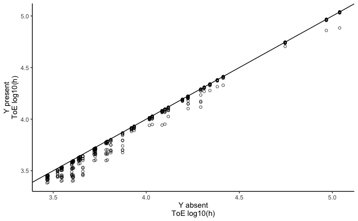

```r
# creating and exporting figure 2
fig2 = ggplot(data = no_interaction_ex, mapping = aes(x = log10(alone), y = log10(X_XY))) + theme_classic() +
  xlab('Y absent\nToE log10(h)') + ylab('Y present\nToE log10(h)') + geom_point(shape = 21, fill = NA, alpha = 3/4) +
  geom_abline(slope = 1, intercept = 0)
fig2
ggsave(plot = fig2, filename = '/Users/jga039/Documents/simulations/analysis/figures_tables/fig_02.tiff', width = 210/2, height = 148/2, units = 'mm', dpi = 300)
```

## Case 2: the two plasmids are epistatic (ie interaction only affects the fitness of doubles).

```r
# subsetting data for the case of epistasis --> Model 3: Interactions affecting fitness (epistasis)
epistasis_ex = singles_extinction[singles_extinction$intrafx1 == '1' & singles_extinction$interfx1 == '1' &
                                      singles_extinction$intrafx2 == '1' & singles_extinction$interfx2 == '1' & singles_extinction$lossxy == '1',]
epistasis_steady = singles_steady_0[singles_steady_0$intrafx1 == '1' & singles_steady_0$interfx1 == '1' &
                                      singles_steady_0$intrafx2 == '1' & singles_steady_0$interfx2 == '1' & singles_steady_0$lossxy == '1',]
# adding column with the fitness of XY to these data sets
epistasis_steady['fit_XY'] = as.numeric(as.character(epistasis_steady$fitness)) * as.numeric(as.character(epistasis_steady$fitness2)) + as.numeric(as.character(epistasis_steady$epistasis))
epistasis_ex['fit_XY'] = as.numeric(as.character(epistasis_ex$fitness)) * as.numeric(as.character(epistasis_ex$fitness2)) + as.numeric(as.character(epistasis_ex$epistasis))
```

### Overview of plasmid maintenance

```r
print(paste('out of', nrow(epistasis_steady), 'cases, the focal plasmid does not go to extinction in', nrow(epistasis_steady[epistasis_steady$X >= 1 | epistasis_steady$XY >= 1, ]), 'with epistasis distributed as:')); table(epistasis_steady[epistasis_steady$X >= 1 | epistasis_steady$XY >= 1, 'epistasis'])
```

```
[1] "out of 1728 cases, the focal plasmid does not go to extinction in 128 with epistasis distributed as:"

-0.05     0  0.05   0.1
    0     0    23   105
```

```r
print(paste('out of', nrow(epistasis_steady), 'total cases,',nrow(epistasis_steady[epistasis_steady$fit_XY > 1, ]), 'have fitness > 1, and of which',
            ifelse(test = all(epistasis_steady[epistasis_steady$fit_XY > 1, 'epistasis'] %in% c('0.05','0.1')), yes = 'all', 'some/none'),
            'have positive epistasis.',nrow(epistasis_steady[epistasis_steady$fit_XY == 1, ]), 'have fitness = 1'))
```

```
[1] "out of 1728 total cases, 135 have fitness > 1, and of which all have positive epistasis. 0 have fitness = 1"
```

```r
tmp = epistasis_steady[epistasis_steady$X >= 1 | epistasis_steady$XY >= 1, ]
print(paste('out of', nrow(tmp), 'survival cases,',nrow(tmp[tmp$fit_XY > 1, ]), 'have fitness > 1, and', nrow(tmp[tmp$fit_XY == 1, ]), 'have fitness = 1'))
```

```
[1] "out of 128 survival cases, 128 have fitness > 1, and 0 have fitness = 1"
```

```r
print(paste('among the',nrow(tmp),'cases of survival the density of XY is always higher than of X & Y?', unique(tmp$X < tmp$XY & tmp$Y < tmp$XY)))
```

```
[1] "among the 128 cases of survival the density of XY is always higher than of X & Y? TRUE"
```

```r
print(paste('there are',nrow(tmp[tmp$O < 1, ]),'cases where there are no plasmid free in the population'))
```

```
[1] "there are 45 cases where there are no plasmid free in the population"
```

```r
tmp2 = epistasis_steady[epistasis_steady$fit_XY >= 1, ]
print(paste('these are the loss parameters leading to no plasmid free in the population:', unique(tmp[tmp$O < 1, 'loss'])))
```

```
[1] "these are the loss parameters leading to no plasmid free in the population: 1e-08"
```

```r
print('In the data set loss is distributed as:')
```

```
[1] "In the data set loss is distributed as:"
```

```r
table(tmp2$loss)
```

```
1e-04 1e-06 1e-08
   45    45    45
```

```r
tmp[tmp$X < 1, 'X'] = 0; tmp[tmp$O < 1, 'O'] = 0; tmp[tmp$XY < 1, 'XY'] = 0; tmp[tmp$Y < 1, 'Y'] = 0
tmp['freqØ'] = tmp$O / (tmp$O + tmp$X + tmp$Y + tmp$XY); tmp['freqX'] = tmp$X / (tmp$O + tmp$X + tmp$Y + tmp$XY)
print(paste('minimum of Ø freq is', 100 * min(tmp$freqØ), '% and the maximum is', 100 * max(tmp$freqØ), '%'))
```

```
[1] "minimum of Ø freq is 0 % and the maximum is 18.6609160698856 %"
```

```r
print(paste('these are the cases of fitness > 1 that go to exctinction:'))
```

```
[1] "these are the cases of fitness > 1 that go to exctinction:"
```

```r
data.frame(apply(X = epistasis_steady[(!(epistasis_steady$X >= 1 | epistasis_steady$XY >= 1)) & epistasis_steady$fit_XY > 1, ], MARGIN = 1, FUN = function(x) { paste(paste(x['focal'], x['competitor'], sep = ' vs '), x['epistasis'], sep = ' and e = ')}))
```

```
     apply.X...epistasis_steady....epistasis_steady.X....1...epistasis_steady.XY....
1576                             1e-13_0.975_1e-04 vs 1e-13_0.975_1e-04 and e = 0.05
1577                             1e-12_0.975_1e-04 vs 1e-13_0.975_1e-04 and e = 0.05
1579                             1e-13_0.975_1e-04 vs 1e-12_0.975_1e-04 and e = 0.05
1580                             1e-12_0.975_1e-04 vs 1e-12_0.975_1e-04 and e = 0.05
1675                                1e-13_0.95_1e-04 vs 1e-13_0.95_1e-04 and e = 0.1
1676                                1e-12_0.95_1e-04 vs 1e-13_0.95_1e-04 and e = 0.1
1678                                1e-13_0.95_1e-04 vs 1e-12_0.95_1e-04 and e = 0.1
```

```r
tmp = epistasis_ex[epistasis_ex$epistasis %in% c('0.05','0.1'),]
print(paste('among the',nrow(epistasis_ex),'cases of extinction, there are',nrow(tmp), 'cases of positive epistasis, such that in:',
            nrow(tmp[as.numeric(as.character(tmp$fitness)) < as.numeric(as.character(tmp$fit_XY)),]), 'XY has higher fitness than X, in',
            nrow(tmp[as.numeric(as.character(tmp$fitness)) > as.numeric(as.character(tmp$fit_XY)),]), 'XY has lower fitness than X, in',
            nrow(tmp[as.numeric(as.character(tmp$fitness)) < as.numeric(as.character(tmp$fit_XY)) & as.numeric(as.character(tmp$fitness2)) < as.numeric(as.character(tmp$fit_XY)),]), 'XY has higher fitness than both X & Y, and in',
            nrow(tmp[as.numeric(as.character(tmp$fitness)) > as.numeric(as.character(tmp$fit_XY)) & as.numeric(as.character(tmp$fitness2)) > as.numeric(as.character(tmp$fit_XY)),]), 'XY has lower fitness than both X & Y'))
```

```
[1] "among the 1600 cases of extinction, there are 736 cases of positive epistasis, such that in: 412 XY has higher fitness than X, in 324 XY has lower fitness than X, in 223 XY has higher fitness than both X & Y, and in 135 XY has lower fitness than both X & Y"
```

Among the surviving cases the double XY is always present at higher frequencies in the population. Among the 736 cases of positive epistasis that go to extinction XY has higher fitness than both X & Y in 223.

```r
tmp = epistasis_ex[epistasis_ex$epistasis %in% c('0.05','0.1'),]
tmp = tmp[as.numeric(as.character(tmp$fitness)) > as.numeric(as.character(tmp$fit_XY)) & as.numeric(as.character(tmp$fitness2)) > as.numeric(as.character(tmp$fit_XY)),]
print(paste('Among the',nrow(tmp),'cases of positive epistasis where XY the least fit, is XY the plasmidic entity faster getting extinct?', paste(unique(tmp$X > tmp$XY & tmp$Y > tmp$XY), collapse = '/')))
```

```
[1] "Among the 135 cases of positive epistasis where XY the least fit, is XY the plasmidic entity faster getting extinct? TRUE"
```

But if XY is the least fit it is the least stable.

```r
tmp = epistasis_ex[epistasis_ex$epistasis %in% c('0.05','0.1'),]
tmp = tmp[as.numeric(as.character(tmp$fitness)) < as.numeric(as.character(tmp$fit_XY)) & as.numeric(as.character(tmp$fitness2)) < as.numeric(as.character(tmp$fit_XY)),]
print(paste('Among the',nrow(tmp),'cases of positive epistasis where XY is the fitest, is XY the plasmidic entity taking longer to get extinct?', paste(unique(tmp$X < tmp$XY & tmp$Y < tmp$XY), collapse = '/')))
```

```
[1] "Among the 223 cases of positive epistasis where XY is the fitest, is XY the plasmidic entity taking longer to get extinct? FALSE/TRUE"
```

```r
table(tmp$X < tmp$XY & tmp$Y < tmp$XY)
```

```
FALSE  TRUE
  165    58
```

Therefore, even if XY is fitter, doesn’t mean it is more stable.

```r
tmp = epistasis_ex[epistasis_ex$epistasis == '-0.05',]
print(paste('among the',nrow(epistasis_ex),'cases of extinction, there are',nrow(tmp), 'cases of negative epistasis. Does XY always have lower fitness than both X & Y?',
            unique(as.numeric(as.character(tmp$fitness)) > as.numeric(as.character(tmp$fit_XY)) & as.numeric(as.character(tmp$fitness2)) > as.numeric(as.character(tmp$fit_XY)))))
```

```
[1] "among the 1600 cases of extinction, there are 432 cases of negative epistasis. Does XY always have lower fitness than both X & Y? TRUE"
```

```r
print(paste('then is XY the plasmidic entity faster getting extinct?', paste(unique(tmp$X > tmp$XY & tmp$Y > tmp$XY), collapse = '/')))
```

```
[1] "then is XY the plasmidic entity faster getting extinct? TRUE/FALSE"
```

```r
table(tmp$X > tmp$XY & tmp$Y > tmp$XY)
```

```
FALSE  TRUE
   12   420
```

```r
print(paste('these are the cases of negative epistasis where XY is not the entity going faster to exctinction:'))
```

```
[1] "these are the cases of negative epistasis where XY is not the entity going faster to exctinction:"
```

```r
tmp2 = tmp[!(tmp$X > tmp$XY & tmp$Y > tmp$XY),]
tmp2[,c('X','XY','Y','focal','competitor','epistasis')]
```

```
         X   XY      Y             focal        competitor epistasis
468 109366 2433   2411 1e-11_0.975_1e-08  1e-11_0.85_1e-08     -0.05
504 109253 3799   3769 1e-11_0.975_1e-08   1e-11_0.9_1e-08     -0.05
540 108572 8421   8372 1e-11_0.975_1e-08  1e-11_0.95_1e-08     -0.05
549   2411 2433 109366  1e-11_0.85_1e-08 1e-11_0.975_1e-08     -0.05
558   3769 3799 109253   1e-11_0.9_1e-08 1e-11_0.975_1e-08     -0.05
567   8372 8421 108572  1e-11_0.95_1e-08 1e-11_0.975_1e-08     -0.05
855  92752 2433   2411 1e-11_0.975_1e-06  1e-11_0.85_1e-06     -0.05
891  92640 3798   3771 1e-11_0.975_1e-06   1e-11_0.9_1e-06     -0.05
927  91960 8425   8411 1e-11_0.975_1e-06  1e-11_0.95_1e-06     -0.05
936   2411 2433  92752  1e-11_0.85_1e-06 1e-11_0.975_1e-06     -0.05
945   3771 3798  92640   1e-11_0.9_1e-06 1e-11_0.975_1e-06     -0.05
954   8411 8425  91960  1e-11_0.95_1e-06 1e-11_0.975_1e-06     -0.05
```

In all 432 cases of negative epistasis XY is less fit than X & Y, however it is not necessarily the one getting extinct first.

```r
print(paste('these are the cases of negative epistasis, fitness of either (but not both) X & Y is 0.975, loss is not 1e-4, and conjugation of both X & Y is 1e-11:'))
```

```
[1] "these are the cases of negative epistasis, fitness of either (but not both) X & Y is 0.975, loss is not 1e-4, and conjugation of both X & Y is 1e-11:"
```

```r
tmp[tmp$conjugation == '1e-11' & tmp$conjugation2 == '1e-11' & tmp$loss != '1e-04' & (tmp$fitness == '0.975' | tmp$fitness2 == '0.975') & (!(tmp$fitness == '0.975' & tmp$fitness2 == '0.975')), c('focal','competitor')]
```

```
                focal        competitor
468 1e-11_0.975_1e-08  1e-11_0.85_1e-08
504 1e-11_0.975_1e-08   1e-11_0.9_1e-08
540 1e-11_0.975_1e-08  1e-11_0.95_1e-08
549  1e-11_0.85_1e-08 1e-11_0.975_1e-08
558   1e-11_0.9_1e-08 1e-11_0.975_1e-08
567  1e-11_0.95_1e-08 1e-11_0.975_1e-08
855 1e-11_0.975_1e-06  1e-11_0.85_1e-06
891 1e-11_0.975_1e-06   1e-11_0.9_1e-06
927 1e-11_0.975_1e-06  1e-11_0.95_1e-06
936  1e-11_0.85_1e-06 1e-11_0.975_1e-06
945   1e-11_0.9_1e-06 1e-11_0.975_1e-06
954  1e-11_0.95_1e-06 1e-11_0.975_1e-06
```

Thus negatively epistatic doubles can persist longer than one of the singles if conjugation and fitness are high and loss is low.

### Control: solo with fitness >=1

```r
print(paste('XY cells can have fitness >= 1, as:', paste(unique(epistasis_steady$fit_XY)[unique(epistasis_steady$fit_XY) >=1], collapse = ' ; ' )))
```

```
[1] "XY cells can have fitness >= 1, as: 1.000625 ; 1.0025 ; 1.02625 ; 1.050625"
```

```r
ctrl_epis = ctrl_steady_0[ctrl_steady_0$fitness %in% c('1','1.05'),]; ctrl_epis$fitness = factor(ctrl_epis$fitness); ctrl_epis$conjugation = factor(ctrl_epis$conjugation)
print(paste('so a control with a single plasmid with fitness as:', paste(unique(ctrl_epis$fitness), collapse = ' ; ' )))
```

```
[1] "so a control with a single plasmid with fitness as: 1 ; 1.05"
```

```r
print(paste('among these',nrow(ctrl_epis),'the plasmid persists in',nrow(ctrl_epis[ctrl_epis$X >= 1,]),'and goes extinct when:',paste(ctrl_epis[ctrl_epis$X < 1,'focal'], collapse = ' or ')))
```

```
[1] "among these 18 the plasmid persists in 16 and goes extinct when: 1e-13_1_1e-04 or 1e-12_1_1e-04"
```

```r
ctrl_epis['freqØ'] = ctrl_epis$O / (ctrl_epis$O + ctrl_epis$X)
print(paste('Ø freq ranges between:', min(ctrl_epis[ctrl_epis$X >= 1, 'freqØ']), 'and', max(ctrl_epis[ctrl_epis$X >= 1, 'freqØ']),
            'with an average of', mean(ctrl_epis[ctrl_epis$X >= 1, 'freqØ'])))
```

```
[1] "Ø freq ranges between: 2.95877167047449e-06 and 0.100123338534833 with an average of 0.0203146876114044"
```

### How is the time to extinction affected by epistasis?

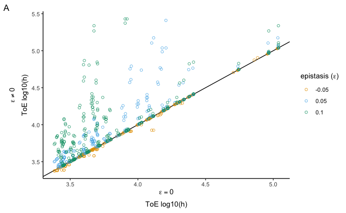

```r
# creating figure 3 panel A
my_palete = colorblind_pal()(4)
p1 = ggplot(data = epistasis_ex[epistasis_ex$epistasis != '0',], mapping = aes(x = log10(no_interaction), y = log10(X_XY), color = epistasis)) +
  theme_classic() + labs(tag = 'A', color = 'ε') + geom_abline(slope = 1, intercept = 0) + geom_point(shape = 21, fill = NA, alpha = 3/4) +
  xlab(bquote(atop(epsilon==0,'ToE log10(h)'))) + ylab(bquote(atop(epsilon!=0,'ToE log10(h)'))) + theme(legend.title.align = 0.5) + scale_color_manual(values = my_palete[2:4], name = expression(paste('epistasis (',epsilon,')')))
p1
```

Performing group comparisons by epistasis.

```r
print(paste('total cases:', nrow(epistasis_ex)))
```

```
[1] "total cases: 1600"
```

```r
epistasis_ex['ratio_e0'] = epistasis_ex$X_XY / epistasis_ex$no_interaction # ratio against no epistasis

# encoding epistasis as factor variables for further analyses
epistasis_ex[epistasis_ex$epistasis == '0', 'epis_fac'] = 'zero'; epistasis_ex[epistasis_ex$epistasis == '-0.05', 'epis_fac'] = 'neg'; epistasis_ex[epistasis_ex$epistasis == '0.05', 'epis_fac'] = 'pos'
epistasis_ex[epistasis_ex$epistasis == '0.1', 'epis_fac'] = 'pos_plus'; epistasis_ex$epis_fac = as.factor(x = epistasis_ex$epis_fac)
epistasis_ex['outcome_epis0'] = ifelse(epistasis_ex$ratio_e0 < 1, 'decrease', 'increase'); epistasis_ex[epistasis_ex$ratio_e0 == 1, 'outcome_epis0'] = 'no effect'
epistasis_ex$outcome_epis0 = as.factor(x = epistasis_ex$outcome_epis0)


x2 = as.data.frame(t(unlist(kruskal.test(x = epistasis_ex$ratio_e0, g = epistasis_ex$epis_fac))))[c(4,2:3)] # result of kruskal test

# summarizing the stats of the quantitative analysis
x1 = data.frame()
for(i in unique(epistasis_ex$epistasis)) { x1 = rbind(x1,cbind(i,median(epistasis_ex[epistasis_ex$epistasis == i,'ratio_e0']),sd(epistasis_ex[epistasis_ex$epistasis == i,'ratio_e0']))) }
colnames(x1) = c('epistasis','median','standard deviation'); x1['subs'] = as.character(x1$epistasis)
dun = dunnTest(ratio_e0 ~ epis_fac, data = epistasis_ex, method = 'bonferroni')$res

# adding results dunn post hoc test
x3 = data.frame(cldList(comparison = dun$Comparison, p.value = dun$P.adj, threshold = 0.05))
subs = data.frame(cond = c('neg','pos','pos_plus','zero'), subs = c('-0.05','0.05','0.1','0'))
for (i in subs$cond) { x3[x3$Group == i,'subs'] = subs[subs$cond == i, 'subs']}
tmp = data.frame(); for(i in x1$subs) { tmp = rbind(tmp, cbind(x1[x1$subs == i, c(1:3)], x3[x3$subs == i, 'Letter']))}
colnames(tmp) = c('interaction value',colnames(tmp)[2:3],"Dunn's test*"); x1 = tmp; x1$`interaction value` = as.character(x1$`interaction value`);  x1 = x1[order(x1$`interaction value`),]

x3 = data.frame('* groups displaying the same letter are not significantly different') # note for letter meaning

# chi square test
x4 = table(epistasis_ex$epis_fac, epistasis_ex$outcome_epis0)
x5 = chisq.test(x = x4, correct = T); x7 = as.data.frame(t(unlist(x5)))[c(4,2:3)]

# Fisher pairwise Nominal Independence test
res = pairwiseNominalIndependence(x = x4, fisher = T, gtest = F, chisq = T, correct = 'yates')

# summarizing the stats of the qualitative analyses
x4 = as.data.frame.matrix(x5$observed); for(i in rownames(x4)) { x4[i,'interaction value'] = subs[subs$cond == i, 'subs']}; x4 = x4[order(x4$`interaction value`),]

x6 = as.data.frame(cldList(comparison = res$Comparison, p.value = res$p.adj.Fisher, threshold = .05))
for(i in x6$Group) { x4[i, "Fisher's exact test pairwise Nominal Independence*"] = x6[x6$Group == i, 'Letter']}
x4 = x4[,c('interaction value',colnames(x4)[colnames(x4) != 'interaction value'])]
colnames(x1)[1] = colnames(x4)[1] = 'epistasis (ε)'

# creating Supp.TableS2
addWorksheet(wb, sheetName = "Supp.TableS2")
writeData(wb, sheet = 2, x = x2, startCol = 1, startRow = 1, borders = 'surrounding')
writeData(wb, sheet = 2, x = x1, startCol = 1, startRow = (nrow(x2) + 2), borders = 'all')
writeData(wb, sheet = 2, x = x7, startCol = (ncol(x1) + 2), startRow = 1, borders = 'surrounding')
writeData(wb, sheet = 2, x = x4, startCol = (ncol(x1) + 2), startRow = (nrow(x7) + 2), borders = 'all')
writeData(wb, sheet = 2, x = x3, startCol = 1, startRow = (nrow(x7) + 2 + nrow(x4) + 2), colNames = F)

x2; x1; x7; x4; x3
```

```
                        method parameter.df              p.value
1 Kruskal-Wallis rank sum test            3 2.29867765304463e-90
  epistasis (ε)           median standard deviation Dunn's test*
2         -0.05                1 0.0332913307923255            a
1             0                1                  0            d
3          0.05 1.00023854961832   1.24682312690221            b
4           0.1 1.03470603470603    4.7495261000945            c
                      method parameter.df               p.value
1 Pearson's Chi-squared test            6 2.89020620542361e-172
         epistasis (ε) decrease increase no effect Fisher's exact test pairwise Nominal Independence*
neg              -0.05      147       68       217                                                  a
zero                 0        0        0       432                                                  d
pos               0.05       53      213       143                                                  b
pos_plus           0.1       41      224        62                                                  c
  X...groups.displaying.the.same.letter.are.not.significantly.different.
1    * groups displaying the same letter are not significantly different
```

Significant kruskal wallis - all groups are different: time to extinction normalized by e = 0 increases with the strength of epistasis. Significant Chi square - all groups are different in terms of outcome distribution.

### Can epistasis increase time to extinction relatively to alone?

```r
# creating figure 3 panel B
p2 = ggplot(data = epistasis_ex, mapping = aes(x = log10(alone), y = log10(X_XY), color = epistasis)) +
  theme_classic() + labs(tag = 'B', color = 'ε') +
  geom_abline(slope = 1, intercept = 0) + geom_point(shape = 21, fill = NA, alpha = 3/4) + scale_color_manual(values = my_palete[c(2,1,3:4)], name = expression(paste('epistasis (',epsilon,')'))) +
  xlab('Y absent\nToE log10(hours)') + ylab('Y present\nToE log10(hours)') + theme(legend.title.align = 0.5)
```

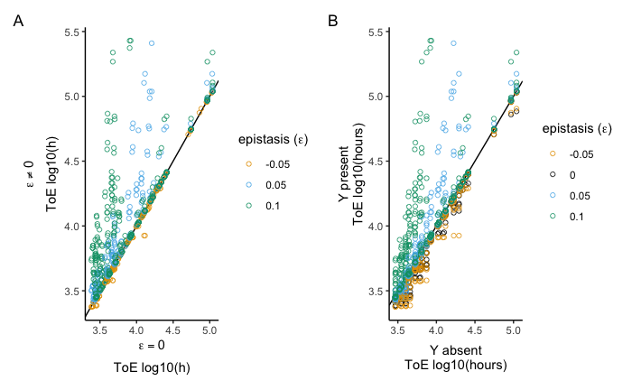

```r
# assembling and exporting figure 3
fig5 = p1 + p2
fig5
ggsave(plot = fig5, filename = '/Users/jga039/Documents/simulations/analysis/figures_tables/fig_03.tiff', width = 210, height = 148/2, units = 'mm', dpi = 300)
```

```r
print(paste('total cases:', nrow(epistasis_ex)))
```

```
[1] "total cases: 1600"
```

```r
epistasis_ex['ratio_alone'] = epistasis_ex$X_XY / epistasis_ex$alone # ratio against absence of competitor

# encoding variable as factor for further analyses
epistasis_ex['outcome_alone'] = ifelse(epistasis_ex$ratio_alone < 1, 'decrease', 'increase'); epistasis_ex[epistasis_ex$ratio_alone == 1, 'outcome_alone'] = 'null'
epistasis_ex$outcome_alone = as.factor(epistasis_ex$outcome_alone)

x2 = as.data.frame(t(unlist(kruskal.test(x = epistasis_ex$ratio_alone, g = epistasis_ex$epis_fac))))[c(4,2:3)] # result of kruskal test

# summarizing the stats of the quantitative analysis
x1 = data.frame()
for(i in unique(epistasis_ex$epistasis)) { x1 = rbind(x1,cbind(i,median(epistasis_ex[epistasis_ex$epistasis == i,'ratio_alone']),sd(epistasis_ex[epistasis_ex$epistasis == i,'ratio_alone']))) }
colnames(x1) = c('epistasis','median','standard deviation'); x1['subs'] = as.character(x1$epistasis)
dun = dunnTest(ratio_alone ~ epis_fac, data = epistasis_ex, method = 'bonferroni')$res

# adding results dunn post hoc test
x3 = data.frame(cldList(comparison = dun$Comparison, p.value = dun$P.adj, threshold = 0.05))
subs = data.frame(cond = c('neg','pos','pos_plus','zero'), subs = c('-0.05','0.05','0.1','0'))
for (i in subs$cond) { x3[x3$Group == i,'subs'] = subs[subs$cond == i, 'subs']}
tmp = data.frame(); for(i in x1$subs) { tmp = rbind(tmp, cbind(x1[x1$subs == i, c(1:3)], x3[x3$subs == i, 'Letter']))}
colnames(tmp) = c('interaction value',colnames(tmp)[2:3],"Dunn's test*"); x1 = tmp; x1$`interaction value` = as.character(x1$`interaction value`);  x1 = x1[order(x1$`interaction value`),]

x3 = data.frame('* groups displaying the same letter are not significantly different') # note for letter meaning

# chi square test
x4 = table(epistasis_ex$epis_fac, epistasis_ex$outcome_alone)
x5 = chisq.test(x = x4, correct = T); x7 = as.data.frame(t(unlist(x5)))[c(4,2:3)]

# Fisher pairwise Nominal Independence test
res = pairwiseNominalIndependence(x = x4, fisher = T, gtest = F, chisq = T, correct = 'yates')
```

```
Chi-squared approximation may be incorrect
```

```r
# summarizing the stats of the qualitative analyses
x4 = as.data.frame.matrix(x5$observed); for(i in rownames(x4)) { x4[i,'interaction value'] = subs[subs$cond == i, 'subs']}; x4 = x4[order(x4$`interaction value`),]
x6 = as.data.frame(cldList(comparison = res$Comparison, p.value = res$p.adj.Fisher, threshold = .05))
for(i in x6$Group) { x4[i, "Fisher's exact test pairwise Nominal Independence*"] = x6[x6$Group == i, 'Letter']}
x4 = x4[,c('interaction value',colnames(x4)[colnames(x4) != 'interaction value'])]
colnames(x1)[1] = colnames(x4)[1] = 'epistasis (ε)'

# creating Supp.TableS3
addWorksheet(wb, sheetName = "Supp.TableS3")
writeData(wb, sheet = 3, x = x2, startCol = 1, startRow = 1, borders = 'surrounding')
writeData(wb, sheet = 3, x = x1, startCol = 1, startRow = (nrow(x2) + 2), borders = 'all')
writeData(wb, sheet = 3, x = x7, startCol = (ncol(x1) + 2), startRow = 1, borders = 'surrounding')
writeData(wb, sheet = 3, x = x4, startCol = (ncol(x1) + 2), startRow = (nrow(x7) + 2), borders = 'all')
writeData(wb, sheet = 3, x = x3, startCol = 1, startRow = (nrow(x7) + 2 + nrow(x4) + 2), colNames = F)

x2; x1; x7; x4; x3
```

```
                        method parameter.df               p.value
1 Kruskal-Wallis rank sum test            3 3.75240524928313e-100
  epistasis (ε)            median standard deviation Dunn's test*
2         -0.05 0.965613099014285  0.103664891620423            a
1             0 0.965778457930647 0.0887027836981159            a
3          0.05 0.988384560400286   1.05076380622362            b
4           0.1  1.01081488933602   3.78234214471763            c
                      method parameter.df               p.value
1 Pearson's Chi-squared test            3 1.53963263509015e-102
         epistasis (ε) decrease increase Fisher's exact test pairwise Nominal Independence*
neg              -0.05      432        0                                                  a
zero                 0      432        0                                                  a
pos               0.05      303      106                                                  b
pos_plus           0.1      158      169                                                  c
  X...groups.displaying.the.same.letter.are.not.significantly.different.
1    * groups displaying the same letter are not significantly different
```

Significant kruskal wallis - e < 0 and e = 0 are not different, e = 0.05 and e = 0.1 are different between each other and the other groups. Same conclusion for Chisq. Thus some combinations with positive epistasis allow plasmids to persist longer, while with e <= 0 plasmids always go extinct faster.

## Case 3: the focal plasmid as target of intracelular interactions on conjugation.

```r
# subsetting data for the case of intracellular conjugation effects --> Model 4: Intracellular interactions affecting conjugation: 3.4.1    Plasmid X as the target of interactions
intrafx1_ex = singles_extinction[singles_extinction$epistasis == '0' & singles_extinction$interfx1 == '1' &
                                      singles_extinction$intrafx2 == '1' & singles_extinction$interfx2 == '1' & singles_extinction$lossxy == '1',]
intrafx1_steady = singles_steady_0[singles_steady_0$epistasis == '0' & singles_steady_0$interfx1 == '1' &
                                      singles_steady_0$intrafx2 == '1' & singles_steady_0$interfx2 == '1' & singles_steady_0$lossxy == '1',]

# adding column with the conjugation from XY to these data sets
intrafx1_steady['conj_X(Y)'] = as.numeric(as.character(intrafx1_steady$conjugation)) * as.numeric(as.character(intrafx1_steady$intrafx1))
intrafx1_ex['conj_X(Y)'] = as.numeric(as.character(intrafx1_ex$conjugation)) * as.numeric(as.character(intrafx1_ex$intrafx1))
```

### Overview of plasmid maintenance

```r
print(paste('out of', nrow(intrafx1_steady), 'cases, the focal plasmid does not go to extinction in', nrow(intrafx1_steady[intrafx1_steady$X >= 1 | intrafx1_steady$XY >= 1, ])))
```

```
[1] "out of 1296 cases, the focal plasmid does not go to extinction in 0"
```

```r
print('the intracelluar conjugation effects on X are distributed as:'); table(intrafx1_steady$intrafx1)
```

```
[1] "the intracelluar conjugation effects on X are distributed as:"

0.001     1    10
  432   432   432
```

X is always doomed to extinction.

### How is the time to extinction affected by intrafx1?

Comparisons by intrafx1.

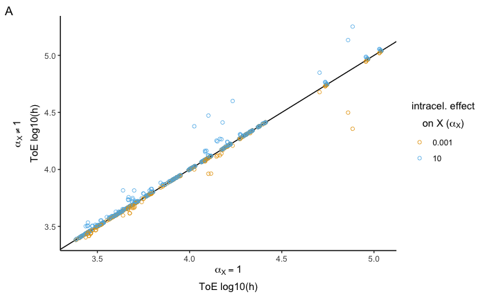

```r
# creating figure 4 panel A
my_palete = colorblind_pal()(3)
p1 = ggplot(data = intrafx1_ex[intrafx1_ex$intrafx1 != '1',], mapping = aes(x = log10(no_interaction), y = log10(X_XY), color = intrafx1)) +
  theme_classic() + labs(tag = 'A', color = expression('α'[X])) + geom_abline(slope = 1, intercept = 0) + geom_point(shape = 21, fill = NA, alpha = 3/4) +
  xlab(bquote(atop(alpha[X]==1,'ToE log10(h)'))) + ylab(bquote(atop(alpha[X]!=1,'ToE log10(h)'))) + theme(legend.title.align = 0.5) + scale_color_manual(values = my_palete[2:3], name = bquote(atop('intracel. effect',paste('on X (',alpha[X],')'))))
p1
```

```r
intrafx1_ex['ratio_a0'] = intrafx1_ex$X_XY / intrafx1_ex$no_interaction # ratio against no interaction

# encoding variable as factor  for further analyses
intrafx1_ex[intrafx1_ex$intrafx1 == '1', 'intrafx1_fac'] = 'null'; intrafx1_ex[intrafx1_ex$intrafx1 == '10', 'intrafx1_fac'] = 'pos'; intrafx1_ex[intrafx1_ex$intrafx1 == '0.001', 'intrafx1_fac'] = 'neg'
intrafx1_ex$intrafx1_fac = as.factor(intrafx1_ex$intrafx1_fac)
intrafx1_ex['outcome_intrafx1'] = ifelse(intrafx1_ex$ratio_a0 < 1, 'decrease', 'increase'); intrafx1_ex[intrafx1_ex$ratio_a0 == 1, 'outcome_intrafx1'] = 'null'
intrafx1_ex$outcome_intrafx1 = as.factor(intrafx1_ex$outcome_intrafx1)

x2 = as.data.frame(t(unlist(kruskal.test(x = intrafx1_ex$ratio_a0, g = intrafx1_ex$intrafx1_fac))))[c(4,2:3)] # result of kruskal test

# summarizing the stats of the quantitative analysis
x1 = data.frame()
for(i in unique(intrafx1_ex$intrafx1)) { x1 = rbind(x1,cbind(i,median(intrafx1_ex[intrafx1_ex$intrafx1 == i,'ratio_a0']),sd(intrafx1_ex[intrafx1_ex$intrafx1 == i,'ratio_a0']))) }
colnames(x1) = c('intrafx1','median','standard deviation'); x1['subs'] = as.character(x1$intrafx1)
dun = dunnTest(ratio_a0 ~ intrafx1_fac, data = intrafx1_ex, method = 'bonferroni')$res

# adding results dunn post hoc test
x3 = data.frame(cldList(comparison = dun$Comparison, p.value = dun$P.adj, threshold = 0.05))
subs = data.frame(cond = c('neg','pos','null'), subs = c('0.001','10','1'))
for (i in subs$cond) { x3[x3$Group == i,'subs'] = subs[subs$cond == i, 'subs']}
tmp = data.frame(); for(i in x1$subs) { tmp = rbind(tmp, cbind(x1[x1$subs == i, c(1:3)], x3[x3$subs == i, 'Letter']))}
colnames(tmp) = c('interaction value',colnames(tmp)[2:3],"Dunn's test*"); x1 = tmp; x1$`interaction value` = as.character(x1$`interaction value`);  x1 = x1[order(x1$`interaction value`),]

x3 = data.frame('* groups displaying the same letter are not significantly different') # note for letter meaning

# chi square test
x4 = table(intrafx1_ex$intrafx1_fac, intrafx1_ex$outcome_intrafx1)
x5 = chisq.test(x = x4, correct = T); x7 = as.data.frame(t(unlist(x5)))[c(4,2:3)]

# Fisher pairwise Nominal Independence test
res = pairwiseNominalIndependence(x = x4, fisher = T, gtest = F, chisq = T, correct = 'yates')
```

```
Chi-squared approximation may be incorrectChi-squared approximation may be incorrect
```

```r
# summarizing the stats of the qualitative analyses
x4 = as.data.frame.matrix(x5$observed); for(i in rownames(x4)) { x4[i,'interaction value'] = subs[subs$cond == i, 'subs']}; x4 = x4[order(x4$`interaction value`),]
x6 = as.data.frame(cldList(comparison = res$Comparison, p.value = res$p.adj.Fisher, threshold = .05))
for(i in x6$Group) { x4[i, "Fisher's exact test pairwise Nominal Independence*"] = x6[x6$Group == i, 'Letter']}
x4 = x4[,c('interaction value',colnames(x4)[colnames(x4) != 'interaction value'])]
colnames(x1)[1] = colnames(x4)[1] = 'intracel. effect on X (αx)'

# creating Supp.TableS4
addWorksheet(wb, sheetName = "Supp.TableS4")
writeData(wb, sheet = 4, x = x2, startCol = 1, startRow = 1, borders = 'surrounding')
writeData(wb, sheet = 4, x = x1, startCol = 1, startRow = (nrow(x2) + 2), borders = 'all')
writeData(wb, sheet = 4, x = x7, startCol = (ncol(x1) + 2), startRow = 1, borders = 'surrounding')
writeData(wb, sheet = 4, x = x4, startCol = (ncol(x1) + 2), startRow = (nrow(x7) + 2), borders = 'all')
writeData(wb, sheet = 4, x = x3, startCol = 1, startRow = (nrow(x7) + 2 + nrow(x4) + 2), colNames = F)

x2; x1; x7; x4; x3
```

```
                        method parameter.df               p.value
1 Kruskal-Wallis rank sum test            2 4.47750853661227e-145
  intracel. effect on X (αx)           median standard deviation Dunn's test*
2                      0.001                1 0.0500039260648051            a
1                          1                1                  0            b
3                         10 1.00018553101338  0.144780620488102            c
                      method parameter.df               p.value
1 Pearson's Chi-squared test            4 1.81816641005621e-217
     intracel. effect on X (αx) decrease increase null Fisher's exact test pairwise Nominal Independence*
neg                       0.001      198        0  234                                                  a
null                          1        0        0  432                                                  b
pos                          10        0      247  185                                                  c
  X...groups.displaying.the.same.letter.are.not.significantly.different.
1    * groups displaying the same letter are not significantly different
```

### Can intrafx1 increase time to extinction relatively to alone?

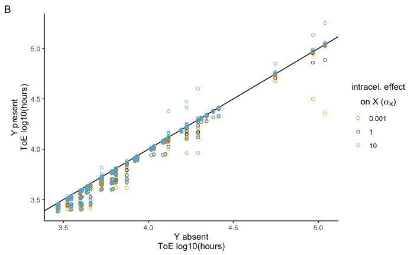

```r
# creating figure 4 panel B
p2 = ggplot(data = intrafx1_ex, mapping = aes(x = log10(alone), y = log10(X_XY), color = intrafx1)) +
  theme_classic() + labs(tag = 'B', color = expression('α'[X])) + geom_abline(slope = 1, intercept = 0) + geom_point(shape = 21, fill = NA, alpha = 3/4) +
  xlab('Y absent\nToE log10(hours)') + ylab('Y present\nToE log10(hours)') + theme(legend.title.align = 0.5) + scale_color_manual(values = my_palete[c(2,1,3)], name = bquote(atop('intracel. effect',paste('on X (',alpha[X],')'))))
p2
```

```r
intrafx1_ex['ratio_alone'] = intrafx1_ex$X_XY / intrafx1_ex$alone # ratio against absence of competitor

# encoding variable as factor for further analyses
intrafx1_ex['outcome_alone'] = ifelse(intrafx1_ex$ratio_alone < 1, 'decrease', 'increase'); intrafx1_ex[intrafx1_ex$ratio_alone == 1, 'outcome_alone'] = 'null'
intrafx1_ex$outcome_alone = as.factor(intrafx1_ex$outcome_alone)

x2 = as.data.frame(t(unlist(kruskal.test(x = intrafx1_ex$ratio_alone, g = intrafx1_ex$intrafx1_fac))))[c(4,2:3)] # result of kruskal test

# summarizing the stats of the quantitative analysis
x1 = data.frame()
for(i in unique(intrafx1_ex$intrafx1)) { x1 = rbind(x1,cbind(i,median(intrafx1_ex[intrafx1_ex$intrafx1 == i,'ratio_alone']),sd(intrafx1_ex[intrafx1_ex$intrafx1 == i,'ratio_alone']))) }
colnames(x1) = c('intrafx1','median','standard deviation'); x1['subs'] = as.character(x1$intrafx1)
dun = dunnTest(ratio_alone ~ intrafx1_fac, data = intrafx1_ex, method = 'bonferroni')$res

# adding results dunn post hoc test
x3 = data.frame(cldList(comparison = dun$Comparison, p.value = dun$P.adj, threshold = 0.05))
for (i in subs$cond) { x3[x3$Group == i,'subs'] = subs[subs$cond == i, 'subs']}
tmp = data.frame(); for(i in x1$subs) { tmp = rbind(tmp, cbind(x1[x1$subs == i, c(1:3)], x3[x3$subs == i, 'Letter']))}
colnames(tmp) = c('interaction value',colnames(tmp)[2:3],"Dunn's test*"); x1 = tmp; x1$`interaction value` = as.character(x1$`interaction value`);  x1 = x1[order(x1$`interaction value`),]

x3 = data.frame('* groups displaying the same letter are not significantly different') # note for letter meaning

# chi square test
x4 = table(intrafx1_ex$intrafx1_fac, intrafx1_ex$outcome_alone)
x5 = chisq.test(x = x4, correct = T); x7 = as.data.frame(t(unlist(x5)))[c(4,2:3)]

# Fisher pairwise Nominal Independence test
res = pairwiseNominalIndependence(x = x4, fisher = T, gtest = F, chisq = F, correct = 'yates')

# summarizing the stats of the qualitative analyses
x4 = as.data.frame.matrix(x5$observed); for(i in rownames(x4)) { x4[i,'interaction value'] = subs[subs$cond == i, 'subs']}; x4 = x4[order(x4$`interaction value`),]
x6 = as.data.frame(cldList(comparison = res$Comparison, p.value = res$p.adj.Fisher, threshold = .05))
for(i in x6$Group) { x4[i, "Fisher's exact test pairwise Nominal Independence*"] = x6[x6$Group == i, 'Letter']}
x4 = x4[,c('interaction value',colnames(x4)[colnames(x4) != 'interaction value'])]
colnames(x1)[1] = colnames(x4)[1] = 'intracel. effect on X (αX)'

# creating Supp.TableS5
addWorksheet(wb, sheetName = "Supp.TableS5")
writeData(wb, sheet = 5, x = x2, startCol = 1, startRow = 1, borders = 'surrounding')
writeData(wb, sheet = 5, x = x1, startCol = 1, startRow = (nrow(x2) + 2), borders = 'all')
writeData(wb, sheet = 5, x = x7, startCol = (ncol(x1) + 2), startRow = 1, borders = 'surrounding')
writeData(wb, sheet = 5, x = x4, startCol = (ncol(x1) + 2), startRow = (nrow(x7) + 2), borders = 'all')
writeData(wb, sheet = 5, x = x3, startCol = 1, startRow = (nrow(x7) + 2 + nrow(x4) + 2), colNames = F)

x2; x1; x7; x4; x3
```

```
                        method parameter.df              p.value
1 Kruskal-Wallis rank sum test            2 1.29486725099011e-06
  intracel. effect on X (αX)            median standard deviation Dunn's test*
2                      0.001 0.964589984161584  0.107567189625147            a
1                          1 0.965778457930647 0.0887027836981159            a
3                         10 0.975425831645619  0.128675270807403            b
                      method parameter.df              p.value
1 Pearson's Chi-squared test            2 1.93767141942754e-21
     intracel. effect on X (αX) decrease increase Fisher's exact test pairwise Nominal Independence*
neg                       0.001      432        0                                                  a
null                          1      432        0                                                  a
pos                          10      386       46                                                  b
  X...groups.displaying.the.same.letter.are.not.significantly.different.
1    * groups displaying the same letter are not significantly different
```

Significant kruskal wallis - intrafx1 < 0 and intrafx1 = 0 are not different, intrafx1 > 1 is different from the other groups.

```r
print('distribuition of conjugation efficiencies leading to increased time to extinction:')
```

```
[1] "distribuition of conjugation efficiencies leading to increased time to extinction:"
```

```r
table(intrafx1_ex[intrafx1_ex$outcome_alone == 'increase','conjugation'])
```

```
1e-13 1e-12 1e-11
    0     0    46
```

### Control: solo with conjugation = -10

```r
ctrl_intrafx = ctrl_steady_0[ctrl_steady_0$conjugation == '1e-10',]; ctrl_intrafx$fitness = factor(ctrl_intrafx$fitness); ctrl_intrafx$conjugation = factor(ctrl_intrafx$conjugation)
print(paste(nrow(ctrl_intrafx),'control single plasmids with conjugation of:', unique(ctrl_intrafx$conjugation)))
```

```
[1] "12 control single plasmids with conjugation of: 1e-10"
```

```r
print(paste('among these',nrow(ctrl_intrafx),'the plasmid persists in',nrow(ctrl_intrafx[ctrl_intrafx$X >= 1,]),'and goes extinct when:',paste(ctrl_intrafx[ctrl_intrafx$X < 1,'focal'], collapse = ' or ')))
```

```
[1] "among these 12 the plasmid persists in 12 and goes extinct when: "
```

```r
ctrl_intrafx['freqØ'] = ctrl_intrafx$O / (ctrl_intrafx$O + ctrl_intrafx$X)
print(paste('Ø freq ranges between:', min(ctrl_intrafx[ctrl_intrafx$X >= 1, 'freqØ']), 'and', max(ctrl_intrafx[ctrl_intrafx$X >= 1, 'freqØ']),
            'with an average of', mean(ctrl_intrafx[ctrl_intrafx$X >= 1, 'freqØ'])))
```

```
[1] "Ø freq ranges between: 1.1487246657551e-06 and 0.0780071851713584 with an average of 0.0105778778171037"
```

## Case 4: the competitor plasmid as target of intracelular interactions on conjugation.

```r
# subsetting data for the case of intracellular conjugation effects --> Model 4: Intracellular interactions affecting conjugation: 3.4.2    Plasmid Y as the target of interactions
intrafx2_ex = singles_extinction[singles_extinction$epistasis == '0' & singles_extinction$intrafx1 == '1' &
                                   singles_extinction$interfx1 == '1' & singles_extinction$interfx2 == '1' & singles_extinction$lossxy == '1',]
intrafx2_steady = singles_steady_0[singles_steady_0$epistasis == '0' & singles_steady_0$intrafx1 == '1' &
                                     singles_steady_0$interfx1 == '1' & singles_steady_0$interfx2 == '1' & singles_steady_0$lossxy == '1',]
# adding column with the conjugation from XY to these data sets
intrafx2_steady['conj_X(Y)'] = as.numeric(as.character(intrafx2_steady$conjugation)) * as.numeric(as.character(intrafx2_steady$intrafx2))
intrafx2_ex['conj_X(Y)'] = as.numeric(as.character(intrafx2_ex$conjugation)) * as.numeric(as.character(intrafx2_ex$intrafx2))
```

### Overview of plasmid maintenance

```r
print(paste('out of', nrow(intrafx2_steady), 'cases, the focal plasmid does not go to extinction in', nrow(intrafx2_steady[intrafx2_steady$X >= 1 | intrafx2_steady$XY >= 1, ])))
```

```
[1] "out of 1296 cases, the focal plasmid does not go to extinction in 0"
```

```r
print('the intracelluar conjugation effects on Y are distributed as:'); table(intrafx2_steady$intrafx2)
```

```
[1] "the intracelluar conjugation effects on Y are distributed as:"

0.001     1    10
  432   432   432
```

X is always doomed to extinction.

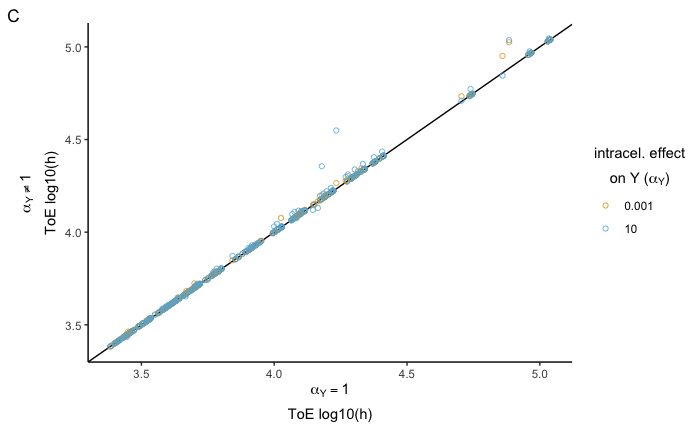

```r
# creating figure 4 panel C
p3 = ggplot(data = intrafx2_ex[intrafx2_ex$intrafx2 != '1',], mapping = aes(x = log10(no_interaction), y = log10(X_XY), color = intrafx2)) +
  theme_classic() + labs(tag = 'C', color = expression('α'[Y])) + geom_abline(slope = 1, intercept = 0) + geom_point(shape = 21, fill = NA, alpha = 3/4) +
  xlab(bquote(atop(alpha[Y]==1,'ToE log10(h)'))) + ylab(bquote(atop(alpha[Y]!=1,'ToE log10(h)'))) + theme(legend.title.align = 0.5) + scale_color_manual(values = my_palete[2:4], name = bquote(atop('intracel. effect',paste('on Y (',alpha[Y],')'))))
p3
```

```r
intrafx2_ex['ratio_a0'] = intrafx2_ex$X_XY / intrafx2_ex$no_interaction # ratio against no interaction

# encoding variable as factor  for further analyses
intrafx2_ex[intrafx2_ex$intrafx2 == '1', 'intrafx2_fac'] = 'null'; intrafx2_ex[intrafx2_ex$intrafx2 == '10', 'intrafx2_fac'] = 'pos'; intrafx2_ex[intrafx2_ex$intrafx2 == '0.001', 'intrafx2_fac'] = 'neg'
intrafx2_ex$intrafx2_fac = as.factor(intrafx2_ex$intrafx2_fac)
intrafx2_ex['outcome_intrafx2'] = ifelse(intrafx2_ex$ratio_a0 < 1, 'decrease', 'increase'); intrafx2_ex[intrafx2_ex$ratio_a0 == 1, 'outcome_intrafx2'] = 'null'
intrafx2_ex$outcome_intrafx2 = as.factor(intrafx2_ex$outcome_intrafx2)

x2 = as.data.frame(t(unlist(kruskal.test(x = intrafx2_ex$ratio_a0, g = intrafx2_ex$intrafx2_fac))))[c(4,2:3)] # result of kruskal test

# summarizing the stats of the quantitative analysis
x1 = data.frame()
for(i in unique(intrafx2_ex$intrafx2)) { x1 = rbind(x1,cbind(i,median(intrafx2_ex[intrafx2_ex$intrafx2 == i,'ratio_a0']),sd(intrafx2_ex[intrafx2_ex$intrafx2 == i,'ratio_a0']))) }
colnames(x1) = c('intrafx2','median','standard deviation'); x1['subs'] = as.character(x1$intrafx2)
dun = dunnTest(ratio_a0 ~ intrafx2_fac, data = intrafx2_ex, method = 'bonferroni')$res

# adding results dunn post hoc test
x3 = data.frame(cldList(comparison = dun$Comparison, p.value = dun$P.adj, threshold = 0.05))
subs = data.frame(cond = c('neg','pos','null'), subs = c('0.001','10','1'))
for (i in subs$cond) { x3[x3$Group == i,'subs'] = subs[subs$cond == i, 'subs']}
tmp = data.frame(); for(i in x1$subs) { tmp = rbind(tmp, cbind(x1[x1$subs == i, c(1:3)], x3[x3$subs == i, 'Letter']))}
colnames(tmp) = c('interaction value',colnames(tmp)[2:3],"Dunn's test*"); x1 = tmp; x1$`interaction value` = as.character(x1$`interaction value`);  x1 = x1[order(x1$`interaction value`),]

x3 = data.frame('* groups displaying the same letter are not significantly different') # note for letter meaning

# chi square test
x4 = table(intrafx2_ex$intrafx2_fac, intrafx2_ex$outcome_intrafx2)
x5 = chisq.test(x = x4, correct = T); x7 = as.data.frame(t(unlist(x5)))[c(4,2:3)]

# Fisher pairwise Nominal Independence test
res = pairwiseNominalIndependence(x = x4, fisher = T, gtest = F, chisq = T, correct = 'yates')
```

```
Chi-squared approximation may be incorrect
```

```r
# summarizing the stats of the qualitative analyses
x4 = as.data.frame.matrix(x5$observed); for(i in rownames(x4)) { x4[i,'interaction value'] = subs[subs$cond == i, 'subs']}; x4 = x4[order(x4$`interaction value`),]
x6 = as.data.frame(cldList(comparison = res$Comparison, p.value = res$p.adj.Fisher, threshold = .05))
for(i in x6$Group) { x4[i, "Fisher's exact test pairwise Nominal Independence*"] = x6[x6$Group == i, 'Letter']}
x4 = x4[,c('interaction value',colnames(x4)[colnames(x4) != 'interaction value'])]
colnames(x1)[1] = colnames(x4)[1] = 'intracel. effect on Y (αy)'

# creating Supp.TableS6
addWorksheet(wb, sheetName = "Supp.TableS6")
writeData(wb, sheet = 6, x = x2, startCol = 1, startRow = 1, borders = 'surrounding')
writeData(wb, sheet = 6, x = x1, startCol = 1, startRow = (nrow(x2) + 2), borders = 'all')
writeData(wb, sheet = 6, x = x7, startCol = (ncol(x1) + 2), startRow = 1, borders = 'surrounding')
writeData(wb, sheet = 6, x = x4, startCol = (ncol(x1) + 2), startRow = (nrow(x7) + 2), borders = 'all')
writeData(wb, sheet = 6, x = x3, startCol = 1, startRow = (nrow(x7) + 2 + nrow(x4) + 2), colNames = F)

x2; x1; x7; x4; x3
```

```
                        method parameter.df              p.value
1 Kruskal-Wallis rank sum test            2 7.56614810321429e-40
  intracel. effect on Y (αy) median standard deviation Dunn's test*
2                      0.001      1 0.0235754429084359            a
1                          1      1                  0            b
3                         10      1 0.0617677306243717            c
                      method parameter.df              p.value
1 Pearson's Chi-squared test            4 8.02872157125652e-97
     intracel. effect on Y (αy) decrease increase null Fisher's exact test pairwise Nominal Independence*
neg                       0.001        3      211  218                                                  a
null                          1        0        0  432                                                  b
pos                          10       65      187  180                                                  c
  X...groups.displaying.the.same.letter.are.not.significantly.different.
1    * groups displaying the same letter are not significantly different
```

### Can intrafx2 increase time to extinction relatively to alone?

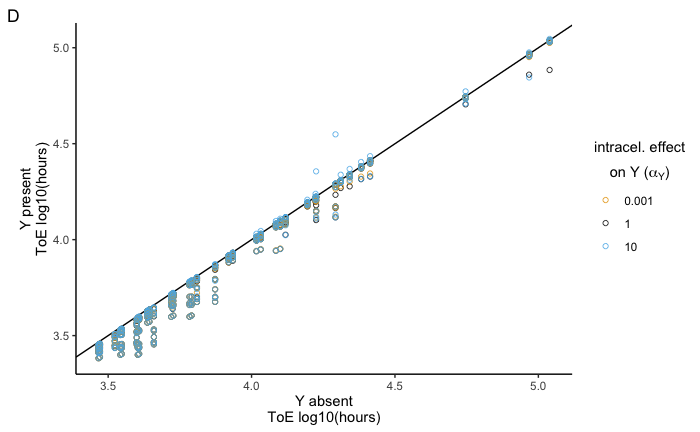

```r
# creating figure 4 panel D
p4 = ggplot(data = intrafx2_ex, mapping = aes(x = log10(alone), y = log10(X_XY), color = intrafx2)) +
  theme_classic() + labs(tag = 'D', color = expression('α'[Y])) + geom_abline(slope = 1, intercept = 0) + geom_point(shape = 21, fill = NA, alpha = 3/4) +
  xlab('Y absent\nToE log10(hours)') + ylab('Y present\nToE log10(hours)') + theme(legend.title.align = 0.5) + scale_color_manual(values = my_palete[c(2,1,3)], name = bquote(atop('intracel. effect',paste('on Y (',alpha[Y],')'))))
p4
```

```r
intrafx2_ex['ratio_alone'] = intrafx2_ex$X_XY / intrafx2_ex$alone # ratio against absence of competitor

# encoding variable as factor for further analyses
intrafx2_ex['outcome_alone'] = ifelse(intrafx2_ex$ratio_alone < 1, 'decrease', 'increase'); intrafx2_ex[intrafx2_ex$ratio_alone == 1, 'outcome_alone'] = 'null'
intrafx2_ex$outcome_alone = as.factor(intrafx2_ex$outcome_alone)

x2 = as.data.frame(t(unlist(kruskal.test(x = intrafx2_ex$ratio_alone, g = intrafx2_ex$intrafx2_fac))))[c(4,2:3)] # result of kruskal test

# summarizing the stats of the quantitative analysis
x1 = data.frame()
for(i in unique(intrafx2_ex$intrafx2)) { x1 = rbind(x1,cbind(i,median(intrafx2_ex[intrafx2_ex$intrafx2 == i,'ratio_alone']),sd(intrafx2_ex[intrafx2_ex$intrafx2 == i,'ratio_alone']))) }
colnames(x1) = c('intrafx2','median','standard deviation')
colnames(x1) = c('interaction value',colnames(x1)[2:3]); x1$`interaction value` = as.character(x1$`interaction value`);  x1 = x1[order(x1$`interaction value`),]

x3 = data.frame('* groups displaying the same letter are not significantly different') # note for letter meaning

# chi square test
x4 = table(intrafx2_ex$intrafx2_fac, intrafx2_ex$outcome_alone)
x5 = chisq.test(x = x4, correct = T); x7 = as.data.frame(t(unlist(x5)))[c(4,2:3)]

# Fisher pairwise Nominal Independence test
res = pairwiseNominalIndependence(x = x4, fisher = T, gtest = F, chisq = F, correct = 'yates')

# summarizing the stats of the qualitative analyses
x4 = as.data.frame.matrix(x5$observed); for(i in rownames(x4)) { x4[i,'interaction value'] = subs[subs$cond == i, 'subs']}; x4 = x4[order(x4$`interaction value`),]
x6 = as.data.frame(cldList(comparison = res$Comparison, p.value = res$p.adj.Fisher, threshold = .05))
for(i in x6$Group) { x4[i, "Fisher's exact test pairwise Nominal Independence*"] = x6[x6$Group == i, 'Letter']}
x4 = x4[,c('interaction value',colnames(x4)[colnames(x4) != 'interaction value'])]
colnames(x1)[1] = colnames(x4)[1] = 'intracel. effect on Y (αy)'

# creating Supp.TableS7
addWorksheet(wb, sheetName = "Supp.TableS7")
writeData(wb, sheet = 7, x = x2, startCol = 1, startRow = 1, borders = 'surrounding')
writeData(wb, sheet = 7, x = x1, startCol = 1, startRow = (nrow(x2) + 2), borders = 'all')
writeData(wb, sheet = 7, x = x7, startCol = (ncol(x1) + 2), startRow = 1, borders = 'surrounding')
writeData(wb, sheet = 7, x = x4, startCol = (ncol(x1) + 2), startRow = (nrow(x7) + 2), borders = 'all')
writeData(wb, sheet = 7, x = x3, startCol = 1, startRow = (nrow(x7) + 2 + nrow(x4) + 2), colNames = F)

x2; x1; x7; x4; x3
```

```
                        method parameter.df           p.value
1 Kruskal-Wallis rank sum test            2 0.058903009918386
  intracel. effect on Y (αy)            median standard deviation
2                      0.001 0.966239776302769 0.0868542247125075
1                          1 0.965778457930647 0.0887027836981159
3                         10 0.971316085489314  0.102306830962445
                      method parameter.df              p.value
1 Pearson's Chi-squared test            2 5.36538737190178e-10
     intracel. effect on Y (αy) decrease increase Fisher's exact test pairwise Nominal Independence*
neg                       0.001      432        0                                                  a
null                          1      432        0                                                  a
pos                          10      411       21                                                  b
  X...groups.displaying.the.same.letter.are.not.significantly.different.
1    * groups displaying the same letter are not significantly different
```

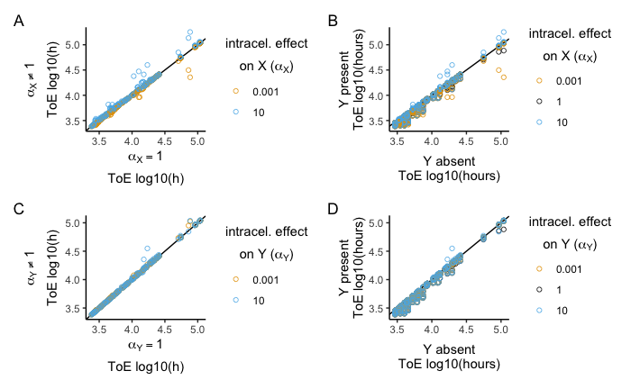

```r
# assembling and exporting figure 4
fig6 = p1 + p2 + p3 + p4
fig6
ggsave(plot = fig6, filename = '/Users/jga039/Documents/simulations/analysis/figures_tables/fig_04.tiff', width = 210, height = 148, units = 'mm', dpi = 300)
```

## Case 5: the focal plasmid as target of intercelular interactions on conjugation.

```r
# subsetting data for the case of intercellular conjugation effects --> 3.5 Model 5: Intercellular interactions affecting conjugation: 3.5.1 Plasmid X as the target of interactions
interfx1_ex = singles_extinction[singles_extinction$epistasis == '0' & singles_extinction$intrafx1 == '1' &
                                      singles_extinction$intrafx2 == '1' & singles_extinction$interfx2 == '1' & singles_extinction$lossxy == '1',]
interfx1_steady = singles_steady_0[singles_steady_0$epistasis == '0' & singles_steady_0$intrafx1 == '1' &
                                      singles_steady_0$intrafx2 == '1' & singles_steady_0$interfx2 == '1' & singles_steady_0$lossxy == '1',]
# adding column with the conjugation from XY to these data sets
interfx1_steady['conj_X(Y)'] = as.numeric(as.character(interfx1_steady$conjugation)) * as.numeric(as.character(interfx1_steady$interfx1))
interfx1_ex['conj_X(Y)'] = as.numeric(as.character(interfx1_ex$conjugation)) * as.numeric(as.character(interfx1_ex$interfx1))
```

### Overview of plasmid maintenance

```r
print(paste('out of', nrow(interfx1_steady), 'cases, the focal plasmid does not go to extinction in', nrow(interfx1_steady[interfx1_steady$X >= 1 | interfx1_steady$XY >= 1, ])))
```

```
[1] "out of 1296 cases, the focal plasmid does not go to extinction in 0"
```

```r
print('the intercelluar conjugation effects on X are distributed as:'); table(interfx1_steady$interfx1)
```

```
[1] "the intercelluar conjugation effects on X are distributed as:"

0.01    1   10
 432  432  432
```

X is always doomed to extinction.

### How is the time to extinction affected by interfx1?

Comparisons by interfx1.

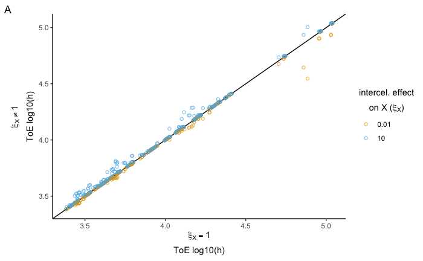

```r
# creating figure 5 panel A
p1 = ggplot(data = interfx1_ex[interfx1_ex$interfx1 != '1',], mapping = aes(x = log10(no_interaction), y = log10(X_XY), color = interfx1)) +
  theme_classic() + labs(tag = 'A', color = expression(xi[X])) + geom_abline(slope = 1, intercept = 0) + geom_point(shape = 21, fill = NA, alpha = 3/4) +
  xlab(bquote(atop(xi[X]==1,'ToE log10(h)'))) + ylab(bquote(atop(xi[X]!=1,'ToE log10(h)'))) + theme(legend.title.align = 0.5) + scale_color_manual(values = my_palete[2:3], name = bquote(atop('intercel. effect',paste('on X (',xi[X],')'))))
p1
```

```r
interfx1_ex['ratio_e0'] = interfx1_ex$X_XY / interfx1_ex$no_interaction # ratio against no interaction

# encoding variable as factor  for further analyses
interfx1_ex[interfx1_ex$interfx1 == '1', 'interfx1_fac'] = 'null'; interfx1_ex[interfx1_ex$interfx1 == '10', 'interfx1_fac'] = 'pos'; interfx1_ex[interfx1_ex$interfx1 == '0.01', 'interfx1_fac'] = 'neg'
interfx1_ex$interfx1_fac = as.factor(interfx1_ex$interfx1_fac)
interfx1_ex['outcome_interfx1'] = ifelse(interfx1_ex$ratio_e0 < 1, 'decrease', 'increase'); interfx1_ex[interfx1_ex$ratio_e0 == 1, 'outcome_interfx1'] = 'null'
interfx1_ex$outcome_interfx1 = as.factor(interfx1_ex$outcome_interfx1)

x2 = as.data.frame(t(unlist(kruskal.test(x = interfx1_ex$ratio_e0, g = interfx1_ex$interfx1_fac))))[c(4,2:3)] # result of kruskal test

# summarizing the stats of the quantitative analysis
x1 = data.frame()
for(i in unique(interfx1_ex$interfx1)) { x1 = rbind(x1,cbind(i,median(interfx1_ex[interfx1_ex$interfx1 == i,'ratio_e0']),sd(interfx1_ex[interfx1_ex$interfx1 == i,'ratio_e0']))) }
colnames(x1) = c('interfx1','median','standard deviation'); x1['subs'] = as.character(x1$interfx1)
dun = dunnTest(ratio_e0 ~ interfx1_fac, data = interfx1_ex, method = 'bonferroni')$res

# adding results dunn post hoc test
x3 = data.frame(cldList(comparison = dun$Comparison, p.value = dun$P.adj, threshold = 0.05))
subs = data.frame(cond = c('neg','pos','null'), subs = c('0.01','10','1'))
for (i in subs$cond) { x3[x3$Group == i,'subs'] = subs[subs$cond == i, 'subs']}
tmp = data.frame(); for(i in x1$subs) { tmp = rbind(tmp, cbind(x1[x1$subs == i, c(1:3)], x3[x3$subs == i, 'Letter']))}
colnames(tmp) = c('interaction value',colnames(tmp)[2:3],"Dunn's test*"); x1 = tmp; x1$`interaction value` = as.character(x1$`interaction value`);  x1 = x1[order(x1$`interaction value`),]

x3 = data.frame('* groups displaying the same letter are not significantly different') # note for letter meaning

# chi square test
x4 = table(interfx1_ex$interfx1_fac, interfx1_ex$outcome_interfx1)
x5 = chisq.test(x = x4, correct = T); x7 = as.data.frame(t(unlist(x5)))[c(4,2:3)]

# Fisher pairwise Nominal Independence test
res = pairwiseNominalIndependence(x = x4, fisher = T, gtest = F, chisq = T, correct = 'yates')
```

```
Chi-squared approximation may be incorrectChi-squared approximation may be incorrect
```

```r
# summarizing the stats of the qualitative analyses
x4 = as.data.frame.matrix(x5$observed); for(i in rownames(x4)) { x4[i,'interaction value'] = subs[subs$cond == i, 'subs']}; x4 = x4[order(x4$`interaction value`),]
x6 = as.data.frame(cldList(comparison = res$Comparison, p.value = res$p.adj.Fisher, threshold = .05))
for(i in x6$Group) { x4[i, "Fisher's exact test pairwise Nominal Independence*"] = x6[x6$Group == i, 'Letter']}
x4 = x4[,c('interaction value',colnames(x4)[colnames(x4) != 'interaction value'])]
colnames(x1)[1] = colnames(x4)[1] = 'intercel. effect on X (ξx)'

# creating Supp.TableS8
addWorksheet(wb, sheetName = "Supp.TableS8")
writeData(wb, sheet = 8, x = x2, startCol = 1, startRow = 1, borders = 'surrounding')
writeData(wb, sheet = 8, x = x1, startCol = 1, startRow = (nrow(x2) + 2), borders = 'all')
writeData(wb, sheet = 8, x = x7, startCol = (ncol(x1) + 2), startRow = 1, borders = 'surrounding')
writeData(wb, sheet = 8, x = x4, startCol = (ncol(x1) + 2), startRow = (nrow(x7) + 2), borders = 'all')
writeData(wb, sheet = 8, x = x3, startCol = 1, startRow = (nrow(x7) + 2 + nrow(x4) + 2), colNames = F)

x2; x1; x7; x4; x3
```

```
                        method parameter.df               p.value
1 Kruskal-Wallis rank sum test            2 8.30043446523006e-230
  intercel. effect on X (ξx)            median standard deviation Dunn's test*
2                       0.01 0.999681661422705 0.0386113131533461            a
1                          1                 1                  0            b
3                         10  1.00206070331721 0.0572856376150954            c
                      method parameter.df p.value
1 Pearson's Chi-squared test            4       0
     intercel. effect on X (ξx) decrease increase null Fisher's exact test pairwise Nominal Independence*
neg                        0.01      313        0  119                                                  a
null                          1        0        0  432                                                  b
pos                          10        0      408   24                                                  c
  X...groups.displaying.the.same.letter.are.not.significantly.different.
1    * groups displaying the same letter are not significantly different
```

```r
print('distribuition of conjugation efficiencies (among ξx == 10) not changing time to extinction:')
```

```
[1] "distribuition of conjugation efficiencies (among ξx == 10) not changing time to extinction:"
```

```r
table(interfx1_ex[interfx1_ex$outcome_interfx1 == 'null' & interfx1_ex$interfx1_fac == 'pos','conjugation'])
```

```
1e-13 1e-12 1e-11
   24     0     0
```

### Can interfx1 increase time to extinction relatively to alone?

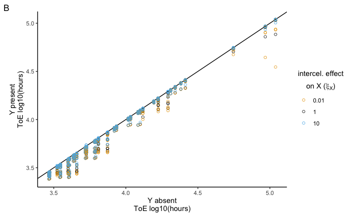

```r
# creating figure 5 panel B
p2 = ggplot(data = interfx1_ex, mapping = aes(x = log10(alone), y = log10(X_XY), color = interfx1)) +
  theme_classic() + labs(tag = 'B', color = expression(xi[X])) + geom_abline(slope = 1, intercept = 0) + geom_point(shape = 21, fill = NA, alpha = 3/4) +
  xlab('Y absent\nToE log10(hours)') + ylab('Y present\nToE log10(hours)') + theme(legend.title.align = 0.5) + scale_color_manual(values = my_palete[c(2,1,3)], name = bquote(atop('intercel. effect',paste('on X (',xi[X],')'))))
p2
```

```r
interfx1_ex['ratio_alone'] = interfx1_ex$X_XY / interfx1_ex$alone # ratio against absence of competitor

# encoding variable as factor for further analyses
interfx1_ex['outcome_alone'] = ifelse(interfx1_ex$ratio_alone < 1, 'decrease', 'increase'); interfx1_ex[interfx1_ex$ratio_alone == 1, 'outcome_alone'] = 'null'
interfx1_ex$outcome_alone = as.factor(interfx1_ex$outcome_alone)

x2 = as.data.frame(t(unlist(kruskal.test(x = interfx1_ex$ratio_alone, g = interfx1_ex$interfx1_fac))))[c(4,2:3)] # result of kruskal test

# summarizing the stats of the quantitative analysis
x1 = data.frame()
for(i in unique(interfx1_ex$interfx1)) { x1 = rbind(x1,cbind(i,median(interfx1_ex[interfx1_ex$interfx1 == i,'ratio_alone']),sd(interfx1_ex[interfx1_ex$interfx1 == i,'ratio_alone']))) }
colnames(x1) = c('interfx1','median','standard deviation'); x1['subs'] = as.character(x1$interfx1)
dun = dunnTest(ratio_alone ~ interfx1_fac, data = interfx1_ex, method = 'bonferroni')$res

# adding results dunn post hoc test
x3 = data.frame(cldList(comparison = dun$Comparison, p.value = dun$P.adj, threshold = 0.05))
for (i in subs$cond) { x3[x3$Group == i,'subs'] = subs[subs$cond == i, 'subs']}
tmp = data.frame(); for(i in x1$subs) { tmp = rbind(tmp, cbind(x1[x1$subs == i, c(1:3)], x3[x3$subs == i, 'Letter']))}
colnames(tmp) = c('interaction value',colnames(tmp)[2:3],"Dunn's test*"); x1 = tmp; x1$`interaction value` = as.character(x1$`interaction value`);  x1 = x1[order(x1$`interaction value`),]

x3 = data.frame('* groups displaying the same letter are not significantly different') # note for letter meaning

# chi square test
x4 = table(interfx1_ex$interfx1_fac, interfx1_ex$outcome_alone)
x5 = chisq.test(x = x4, correct = T); x7 = as.data.frame(t(unlist(x5)))[c(4,2:3)]
```

```
Chi-squared approximation may be incorrect
```

```r
# summarizing the stats of the qualitative analyses
x4 = as.data.frame.matrix(x5$observed); for(i in rownames(x4)) { x4[i,'interaction value'] = subs[subs$cond == i, 'subs']}; x4 = x4[order(x4$`interaction value`),]
x4 = x4[,c('interaction value',colnames(x4)[colnames(x4) != 'interaction value'])]
colnames(x1)[1] = colnames(x4)[1] = 'intercel. effect on X (ξx)'

# creating Supp.TableS3
addWorksheet(wb, sheetName = "Supp.TableS9")
writeData(wb, sheet = 9, x = x2, startCol = 1, startRow = 1, borders = 'surrounding')
writeData(wb, sheet = 9, x = x1, startCol = 1, startRow = (nrow(x2) + 2), borders = 'all')
writeData(wb, sheet = 9, x = x7, startCol = (ncol(x1) + 2), startRow = 1, borders = 'surrounding')
writeData(wb, sheet = 9, x = x4, startCol = (ncol(x1) + 2), startRow = (nrow(x7) + 2), borders = 'all')
writeData(wb, sheet = 9, x = x3, startCol = 1, startRow = (nrow(x7) + 2 + nrow(x4) + 2), colNames = F)

x2; x1; x7; x4; x3
```

```
                        method parameter.df              p.value
1 Kruskal-Wallis rank sum test            2 8.19632433423502e-07
  intercel. effect on X (ξx)            median standard deviation Dunn's test*
2                       0.01 0.963644878480452  0.101154447982393            a
1                          1 0.965778457930647 0.0887027836981159            a
3                         10 0.976058026861547 0.0722566352553944            b
                      method parameter.df            p.value
1 Pearson's Chi-squared test            2 0.0494417259304994
     intercel. effect on X (ξx) decrease increase
neg                        0.01      432        0
null                          1      432        0
pos                          10      429        3
  X...groups.displaying.the.same.letter.are.not.significantly.different.
1    * groups displaying the same letter are not significantly different
```

```r
print('distribuition of cases increasing time to extinction:')
```

```
[1] "distribuition of cases increasing time to extinction:"
```

```r
interfx1_ex[interfx1_ex$outcome_alone == 'increase',c('fitness','conjugation','loss','interfx1')]
```

```
     fitness conjugation  loss interfx1
3862     0.9       1e-11 1e-06       10
4150     0.9       1e-11 1e-04       10
4153     0.9       1e-11 1e-04       10
```

## Case 6: the competitor plasmid as target of intercelular interactions on conjugation.

```r
# subsetting data for the case of intracellular conjugation effects --> 3.5 Model 5: Intercellular interactions affecting conjugation: 3.5.e Plasmid Y as the target of interactions
interfx2_ex = singles_extinction[singles_extinction$epistasis == '0' & singles_extinction$interfx1 == '1' &
                                   singles_extinction$intrafx1 == '1' & singles_extinction$intrafx2 == '1' & singles_extinction$lossxy == '1',]
interfx2_steady = singles_steady_0[singles_steady_0$epistasis == '0' & singles_steady_0$interfx1 == '1' &
                                     singles_steady_0$intrafx1 == '1' & singles_steady_0$intrafx2 == '1' & singles_steady_0$lossxy == '1',]
# adding column with the conjugation from XY to these data sets
interfx2_steady['conj_X(Y)'] = as.numeric(as.character(interfx2_steady$conjugation)) * as.numeric(as.character(interfx2_steady$interfx2))
interfx2_ex['conj_X(Y)'] = as.numeric(as.character(interfx2_ex$conjugation)) * as.numeric(as.character(interfx2_ex$interfx2))
```

### Overview of plasmid maintenance

```r
print(paste('out of', nrow(interfx2_steady), 'cases, the focal plasmid does not go to extinction in', nrow(interfx2_steady[interfx2_steady$X >= 1 | interfx2_steady$XY >= 1, ])))
```

```
[1] "out of 1296 cases, the focal plasmid does not go to extinction in 0"
```

```r
print('the intracelluar conjugation effects on Y are distributed as:'); table(interfx2_steady$interfx2)
```

```
[1] "the intracelluar conjugation effects on Y are distributed as:"

0.01    1   10
 432  432  432
```

X is always doomed to extinction.

### How is the time to extinction affected by interfx2?

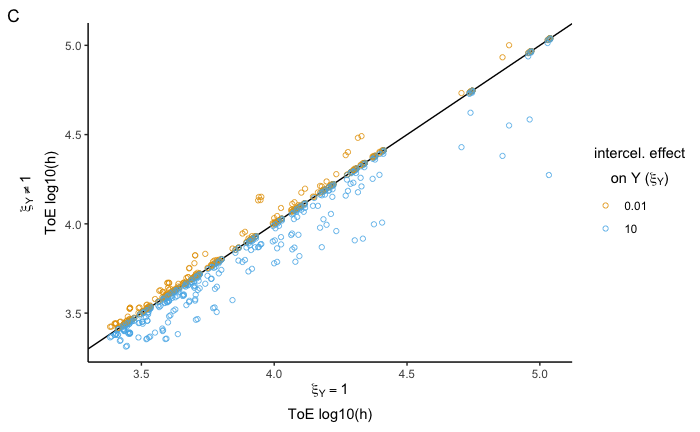

```r
# creating figure 5 panel C
p3 = ggplot(data = interfx2_ex[interfx2_ex$interfx2 != '1',], mapping = aes(x = log10(no_interaction), y = log10(X_XY), color = interfx2)) +
  theme_classic() + labs(tag = 'C', color = expression(xi[Y])) + geom_abline(slope = 1, intercept = 0) + geom_point(shape = 21, fill = NA, alpha = 3/4) +
  xlab(bquote(atop(xi[Y]==1,'ToE log10(h)'))) + ylab(bquote(atop(xi[Y]!=1,'ToE log10(h)'))) + theme(legend.title.align = 0.5) + scale_color_manual(values = my_palete[c(2:3)], name = bquote(atop('intercel. effect',paste('on Y (',xi[Y],')'))))
p3
```

```r
interfx2_ex['ratio_e0'] = interfx2_ex$X_XY / interfx2_ex$no_interaction # ratio against no interaction

# encoding variable as factor  for further analyses
interfx2_ex[interfx2_ex$interfx2 == '1', 'interfx2_fac'] = 'null'; interfx2_ex[interfx2_ex$interfx2 == '10', 'interfx2_fac'] = 'pos'; interfx2_ex[interfx2_ex$interfx2 == '0.01', 'interfx2_fac'] = 'neg'
interfx2_ex$interfx2_fac = as.factor(interfx2_ex$interfx2_fac)
interfx2_ex['outcome_interfx2'] = ifelse(interfx2_ex$ratio_e0 < 1, 'decrease', 'increase'); interfx2_ex[interfx2_ex$ratio_e0 == 1, 'outcome_interfx2'] = 'null'
interfx2_ex$outcome_interfx2 = as.factor(interfx2_ex$outcome_interfx2)

x2 = as.data.frame(t(unlist(kruskal.test(x = interfx2_ex$ratio_e0, g = interfx2_ex$interfx2_fac))))[c(4,2:3)] # result of kruskal test

# summarizing the stats of the quantitative analysis
x1 = data.frame()
for(i in unique(interfx2_ex$interfx2)) { x1 = rbind(x1,cbind(i,median(interfx2_ex[interfx2_ex$interfx2 == i,'ratio_e0']),sd(interfx2_ex[interfx2_ex$interfx2 == i,'ratio_e0']))) }
colnames(x1) = c('interfx2','median','standard deviation'); x1['subs'] = as.character(x1$interfx2)
dun = dunnTest(ratio_e0 ~ interfx2_fac, data = interfx2_ex, method = 'bonferroni')$res

# adding results dunn post hoc test
x3 = data.frame(cldList(comparison = dun$Comparison, p.value = dun$P.adj, threshold = 0.05))
subs = data.frame(cond = c('neg','pos','null'), subs = c('0.01','10','1'))
for (i in subs$cond) { x3[x3$Group == i,'subs'] = subs[subs$cond == i, 'subs']}
tmp = data.frame(); for(i in x1$subs) { tmp = rbind(tmp, cbind(x1[x1$subs == i, c(1:3)], x3[x3$subs == i, 'Letter']))}
colnames(tmp) = c('interaction value',colnames(tmp)[2:3],"Dunn's test*"); x1 = tmp; x1$`interaction value` = as.character(x1$`interaction value`);  x1 = x1[order(x1$`interaction value`),]

x3 = data.frame('* groups displaying the same letter are not significantly different') # note for letter meaning

# chi square test
x4 = table(interfx2_ex$interfx2_fac, interfx2_ex$outcome_interfx2)
x5 = chisq.test(x = x4, correct = T); x7 = as.data.frame(t(unlist(x5)))[c(4,2:3)]

# Fisher pairwise Nominal Independence test
res = pairwiseNominalIndependence(x = x4, fisher = T, gtest = F, chisq = T, correct = 'yates')
```

```
Chi-squared approximation may be incorrectChi-squared approximation may be incorrect
```

```r
# summarizing the stats of the qualitative analyses
x4 = as.data.frame.matrix(x5$observed); for(i in rownames(x4)) { x4[i,'interaction value'] = subs[subs$cond == i, 'subs']}; x4 = x4[order(x4$`interaction value`),]
x6 = as.data.frame(cldList(comparison = res$Comparison, p.value = res$p.adj.Fisher, threshold = .05))
for(i in x6$Group) { x4[i, "Fisher's exact test pairwise Nominal Independence*"] = x6[x6$Group == i, 'Letter']}
x4 = x4[,c('interaction value',colnames(x4)[colnames(x4) != 'interaction value'])]
colnames(x1)[1] = colnames(x4)[1] = 'intercel. effect on Y (ξy)'

# creating Supp.TableS10
addWorksheet(wb, sheetName = "Supp.TableS10")
writeData(wb, sheet = 10, x = x2, startCol = 1, startRow = 1, borders = 'surrounding')
writeData(wb, sheet = 10, x = x1, startCol = 1, startRow = (nrow(x2) + 2), borders = 'all')
writeData(wb, sheet = 10, x = x7, startCol = (ncol(x1) + 2), startRow = 1, borders = 'surrounding')
writeData(wb, sheet = 10, x = x4, startCol = (ncol(x1) + 2), startRow = (nrow(x7) + 2), borders = 'all')
writeData(wb, sheet = 10, x = x3, startCol = 1, startRow = (nrow(x7) + 2 + nrow(x4) + 2), colNames = F)

x2; x1; x7; x4; x3
```

```
                        method parameter.df              p.value
1 Kruskal-Wallis rank sum test            2 5.6611501551636e-252
  intercel. effect on Y (ξy)            median standard deviation Dunn's test*
2                       0.01  1.00175449865398 0.0799284743720024            a
1                          1                 1                  0            b
3                         10 0.980384950684011  0.136400568252953            c
                      method parameter.df p.value
1 Pearson's Chi-squared test            4       0
     intercel. effect on Y (ξy) decrease increase null Fisher's exact test pairwise Nominal Independence*
neg                        0.01        0      393   39                                                  a
null                          1        0        0  432                                                  b
pos                          10      432        0    0                                                  c
  X...groups.displaying.the.same.letter.are.not.significantly.different.
1    * groups displaying the same letter are not significantly different
```

### Can interfx2 increase time to extinction relatively to alone?

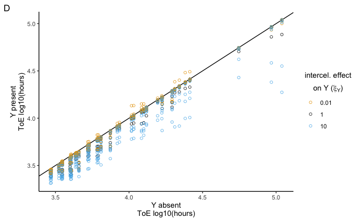

```r
# creating figure 5 panel D
p4 = ggplot(data = interfx2_ex, mapping = aes(x = log10(alone), y = log10(X_XY), color = interfx2)) +
  theme_classic() + labs(tag = 'D', color = expression(xi[Y])) + geom_abline(slope = 1, intercept = 0) + geom_point(shape = 21, fill = NA, alpha = 3/4) +
  xlab('Y absent\nToE log10(hours)') + ylab('Y present\nToE log10(hours)') + theme(legend.title.align = 0.5) + scale_color_manual(values = my_palete[c(2,1,3)], name = bquote(atop('intercel. effect',paste('on Y (',xi[Y],')'))))
p4
```

```r
interfx2_ex['ratio_alone'] = interfx2_ex$X_XY / interfx2_ex$alone # ratio against absence of competitor

# encoding variable as factor for further analyses
interfx2_ex['outcome_alone'] = ifelse(interfx2_ex$ratio_alone < 1, 'decrease', 'increase'); interfx2_ex[interfx2_ex$ratio_alone == 1, 'outcome_alone'] = 'null'
interfx2_ex$outcome_alone = as.factor(interfx2_ex$outcome_alone)

x2 = as.data.frame(t(unlist(kruskal.test(x = interfx2_ex$ratio_alone, g = interfx2_ex$interfx2_fac))))[c(4,2:3)] # result of kruskal test

# summarizing the stats of the quantitative analysis
x1 = data.frame()
for(i in unique(interfx2_ex$interfx2)) { x1 = rbind(x1,cbind(i,median(interfx2_ex[interfx2_ex$interfx2 == i,'ratio_alone']),sd(interfx2_ex[interfx2_ex$interfx2 == i,'ratio_alone']))) }
colnames(x1) = c('interfx2','median','standard deviation'); x1['subs'] = as.character(x1$interfx2)
dun = dunnTest(ratio_alone ~ interfx2_fac, data = interfx2_ex, method = 'bonferroni')$res

# adding results dunn post hoc test
x3 = data.frame(cldList(comparison = dun$Comparison, p.value = dun$P.adj, threshold = 0.05))
for (i in subs$cond) { x3[x3$Group == i,'subs'] = subs[subs$cond == i, 'subs']}
tmp = data.frame(); for(i in x1$subs) { tmp = rbind(tmp, cbind(x1[x1$subs == i, c(1:3)], x3[x3$subs == i, 'Letter']))}
colnames(tmp) = c('interaction value',colnames(tmp)[2:3],"Dunn's test*"); x1 = tmp; x1$`interaction value` = as.character(x1$`interaction value`);  x1 = x1[order(x1$`interaction value`),]

x3 = data.frame('* groups displaying the same letter are not significantly different') # note for letter meaning

# chi square test
x4 = table(interfx2_ex$interfx2_fac, interfx2_ex$outcome_alone)
x5 = chisq.test(x = x4, correct = T); x7 = as.data.frame(t(unlist(x5)))[c(4,2:3)]

# Fisher pairwise Nominal Independence test
res = pairwiseNominalIndependence(x = x4, fisher = T, gtest = F, chisq = F, correct = 'yates')

# summarizing the stats of the qualitative analyses
x4 = as.data.frame.matrix(x5$observed); for(i in rownames(x4)) { x4[i,'interaction value'] = subs[subs$cond == i, 'subs']}; x4 = x4[order(x4$`interaction value`),]
x6 = as.data.frame(cldList(comparison = res$Comparison, p.value = res$p.adj.Fisher, threshold = .05))
for(i in x6$Group) { x4[i, "Fisher's exact test pairwise Nominal Independence*"] = x6[x6$Group == i, 'Letter']}
x4 = x4[,c('interaction value',colnames(x4)[colnames(x4) != 'interaction value'])]
colnames(x1)[1] = colnames(x4)[1] = 'intercel. effect on Y (ξy)'

# creating Supp.TableS11
addWorksheet(wb, sheetName = "Supp.TableS11")
writeData(wb, sheet = 11, x = x2, startCol = 1, startRow = 1, borders = 'surrounding')
writeData(wb, sheet = 11, x = x1, startCol = 1, startRow = (nrow(x2) + 2), borders = 'all')
writeData(wb, sheet = 11, x = x7, startCol = (ncol(x1) + 2), startRow = 1, borders = 'surrounding')
writeData(wb, sheet = 11, x = x4, startCol = (ncol(x1) + 2), startRow = (nrow(x7) + 2), borders = 'all')
writeData(wb, sheet = 11, x = x3, startCol = 1, startRow = (nrow(x7) + 2 + nrow(x4) + 2), colNames = F)

x2; x1; x7; x4; x3
```

```
                        method parameter.df              p.value
1 Kruskal-Wallis rank sum test            2 1.92710494130016e-28
  intercel. effect on Y (ξy)            median standard deviation Dunn's test*
2                       0.01 0.976989972490904 0.0852063292887816            a
1                          1 0.965778457930647 0.0887027836981159            b
3                         10 0.922347891692504  0.157715987848924            c
                      method parameter.df              p.value
1 Pearson's Chi-squared test            2 3.00037611165521e-12
     intercel. effect on Y (ξy) decrease increase Fisher's exact test pairwise Nominal Independence*
neg                        0.01      406       26                                                  a
null                          1      432        0                                                  b
pos                          10      432        0                                                  b
  X...groups.displaying.the.same.letter.are.not.significantly.different.
1    * groups displaying the same letter are not significantly different
```

```r
print('distribuition of Y`s conjugation increasing time to extinction:')
```

```
[1] "distribuition of Y`s conjugation increasing time to extinction:"
```

```r
table(interfx2_ex[interfx2_ex$outcome_alone == 'increase','conjugation2'])
```

```
1e-13 1e-12 1e-11
    0     0    26
```

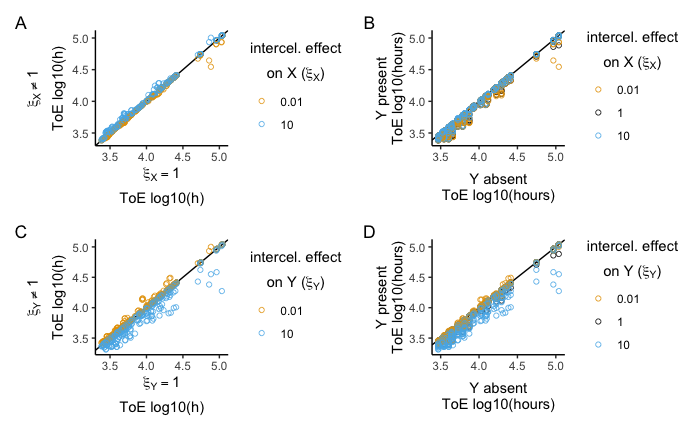

```r
# assembling and exporting figure 5
fig7 = p1 + p2 + p3 + p4
fig7
ggsave(plot = fig7, filename = '/Users/jga039/Documents/simulations/analysis/figures_tables/fig_05.tiff', width = 210, height = 148, units = 'mm', dpi = 300)
```

## Case 7: the plasmids interfere in segregational loss

```r
# subsetting data for the case of intracellular conjugation effects --> Model 6: Interactions affecting Loss
loss_ex = singles_extinction[singles_extinction$epistasis == '0' & singles_extinction$intrafx1 == '1' & singles_extinction$intrafx2 == '1' &
                             singles_extinction$interfx1 == '1' & singles_extinction$interfx2 == '1',]
loss_steady = singles_steady_0[singles_steady_0$epistasis == '0' & singles_steady_0$intrafx1 == '1' & singles_steady_0$intrafx2 == '1' &
                                 singles_steady_0$interfx1 == '1' & singles_steady_0$interfx2 == '1',]
# adding column with the loss from XY to these data sets
loss_steady['loss2'] = as.numeric(as.character(loss_steady$loss)) * as.numeric(as.character(loss_steady$lossxy))
loss_ex['loss2'] = as.numeric(as.character(loss_ex$loss)) * as.numeric(as.character(loss_ex$lossxy))
```

### Overview of plasmid maintenance

```r
print(paste('out of', nrow(loss_steady), 'cases, the focal plasmid does not go to extinction in', nrow(loss_steady[loss_steady$X >= 1 | loss_steady$XY >= 1, ])))
```

```
[1] "out of 864 cases, the focal plasmid does not go to extinction in 0"
```

```r
print('the loss effects are distributed as:'); table(loss_steady$lossxy)
```

```
[1] "the loss effects are distributed as:"

  1  10
432 432
```

X is always doomed to extinction.

### How is the time to extinction affected by lossxy?

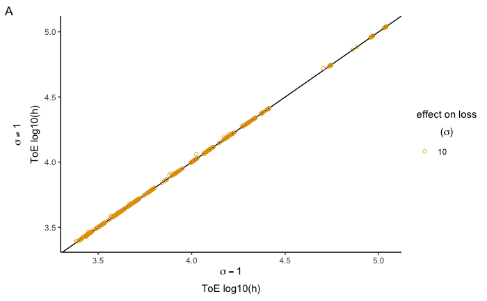

```r
# creating figure 6 panel A
p1 = ggplot(data = loss_ex[loss_ex$lossxy != '1',], mapping = aes(x = log10(no_interaction), y = log10(X_XY), color = lossxy)) +
  theme_classic() + labs(tag = 'A', color = expression(sigma)) + geom_abline(slope = 1, intercept = 0) + geom_point(shape = 21, fill = NA, alpha = 3/4) +
  xlab(bquote(atop(sigma==1,'ToE log10(h)'))) + ylab(bquote(atop(sigma!=1,'ToE log10(h)'))) + theme(legend.title.align = 0.5) + scale_color_manual(values = my_palete[2], name = bquote(atop('effect on loss',paste('(',sigma,')'))))
p1
```

```r
loss_ex['ratio_e0'] = loss_ex$X_XY / loss_ex$no_interaction # ratio against no interaction

# encoding variable as factor  for further analyses
loss_ex['loss_fac'] = ifelse(test = loss_ex$lossxy == '1', yes = 'null', no = 'fx'); loss_ex$loss_fac = as.factor(loss_ex$loss_fac)
loss_ex['outcome_loss'] = ifelse(loss_ex$ratio_e0 < 1, 'decrease', 'increase'); loss_ex[loss_ex$ratio_e0 == 1, 'outcome_loss'] = 'null'
loss_ex$outcome_loss = as.factor(loss_ex$outcome_loss)

x2 = as.data.frame(t(unlist(wilcox.test(x = loss_ex[loss_ex$loss_fac == 'fx', 'ratio_e0'], mu = 1, correct = T))))[c(5:4,2)] # result of wilcox test

# summarizing the stats of the quantitative analysis
x1 = data.frame()
for(i in unique(loss_ex$lossxy)) { x1 = rbind(x1,cbind(i,median(loss_ex[loss_ex$lossxy == i,'ratio_e0']),sd(loss_ex[loss_ex$lossxy == i,'ratio_e0']))) }
colnames(x1) = c('lossxy','median','standard deviation'); x1['subs'] = as.character(x1$lossxy)
colnames(x1) = c('interaction value',colnames(x1)[2:3]); x1$`interaction value` = as.character(x1$`interaction value`);  x1 = x1[order(x1$`interaction value`),]
subs = data.frame(cond = c('null','fx'), subs = c('1','10'))

# chi square test
x4 = table(loss_ex$loss_fac, loss_ex$outcome_loss)
x5 = chisq.test(x = x4, correct = T); x7 = as.data.frame(t(unlist(x5)))[c(4,2:3)]

# Fisher pairwise Nominal Independence test
res = pairwiseNominalIndependence(x = x4, fisher = T, gtest = F, chisq = T, correct = 'yates')

# summarizing the stats of the qualitative analyses
x4 = as.data.frame.matrix(x5$observed); for(i in rownames(x4)) { x4[i,'interaction value'] = subs[subs$cond == i, 'subs']}; x4 = x4[order(x4$`interaction value`),]
x4 = x4[,c('interaction value',colnames(x4)[colnames(x4) != 'interaction value'])]
colnames(x1)[1] = colnames(x4)[1] = 'effect on loss (σ)'

# creating Supp.TableS12
addWorksheet(wb, sheetName = "Supp.TableS12")
writeData(wb, sheet = 12, x = x2, startCol = 1, startRow = 1, borders = 'surrounding')
writeData(wb, sheet = 12, x = x1[,1:(ncol(x1)-1)], startCol = 1, startRow = (nrow(x2) + 2), borders = 'all')
writeData(wb, sheet = 12, x = x7, startCol = (ncol(x1) + 2), startRow = 1, borders = 'surrounding')
writeData(wb, sheet = 12, x = x4, startCol = (ncol(x1) + 2), startRow = (nrow(x7) + 2), borders = 'all')

x2; x1[,1:(ncol(x1)-1)]; x7; x4
```

```
                                                method alternative              p.value
1 Wilcoxon signed rank test with continuity correction   two.sided 1.90473894552546e-24
  effect on loss (σ) median  standard deviation
1                  1      1                   0
2                 10      1 0.00755659319581571
                      method parameter.df              p.value
1 Pearson's Chi-squared test            2 7.62872824992063e-52
     effect on loss (σ) decrease increase null
null                  1        0        0  432
fx                   10       15      170  247
```

There is a significant difference between groups but the effect is very small.

```r
print('distribuition of cases decreasing time to extinction:')
```

```
[1] "distribuition of cases decreasing time to extinction:"
```

```r
table(loss_ex[loss_ex$outcome_loss == 'decrease',c('fitness2','loss','loss_fac')])
```

```
, , loss_fac = fx

        loss
fitness2 1e-04 1e-06 1e-08
   0.85      0     0     0
   0.9       0     0     0
   0.95      0     0     0
   0.975     3    11     1

, , loss_fac = null

        loss
fitness2 1e-04 1e-06 1e-08
   0.85      0     0     0
   0.9       0     0     0
   0.95      0     0     0
   0.975     0     0     0
```

### Can loss effect increase time to extinction relatively to alone?

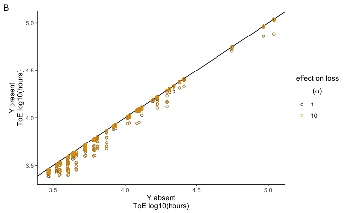

```r
# creating figure 6 panel B
p2 = ggplot(data = loss_ex, mapping = aes(x = log10(alone), y = log10(X_XY), color = lossxy)) +
  theme_classic() + labs(tag = 'B', color = expression(sigma)) + geom_abline(slope = 1, intercept = 0) + geom_point(shape = 21, fill = NA, alpha = 3/4) +
  xlab('Y absent\nToE log10(hours)') + ylab('Y present\nToE log10(hours)') + theme(legend.title.align = 0.5) + scale_color_manual(values = my_palete[c(1:2)], name = bquote(atop('effect on loss',paste('(',sigma,')'))))
p2
```

```r
loss_ex['ratio_alone'] = loss_ex$X_XY / loss_ex$alone # ratio against absence of competitor

# encoding variable as factor for further analyses
loss_ex['outcome_alone'] = ifelse(loss_ex$ratio_alone < 1, 'decrease', 'increase'); loss_ex[loss_ex$ratio_alone == 1, 'outcome_alone'] = 'null'
loss_ex$outcome_alone = as.factor(loss_ex$outcome_alone)

x2 = as.data.frame(t(unlist(wilcox.test(x = loss_ex[loss_ex$loss_fac == 'fx', 'ratio_alone'], mu = 1, correct = T))))[c(5:4,2)] # result of wilcox test

# summarizing the stats of the quantitative analysis
x1 = data.frame()
for(i in unique(loss_ex$lossxy)) { x1 = rbind(x1,cbind(i,median(loss_ex[loss_ex$lossxy == i,'ratio_alone']),sd(loss_ex[loss_ex$lossxy == i,'ratio_alone']))) }
colnames(x1) = c('lossxy','median','standard deviation'); x1['subs'] = as.character(x1$lossxy); colnames(x1)[1] = 'interaction value'

# chi square test
x4 = table(loss_ex$loss_fac, loss_ex$outcome_alone)
x5 = chisq.test(x = x4, correct = T); x7 = as.data.frame(t(unlist(x5)))[c(4,2:3)]

# summarizing the stats of the qualitative analyses
x4 = as.data.frame(as.matrix(x5$observed)); x4['interaction value'] = subs$subs; x4 = x4[,c(2:1)]; colnames(x4)[2] = 'decrease'
colnames(x1)[1] = colnames(x4)[1] = 'effect on loss (σ)'

# creating Supp.TableS3
addWorksheet(wb, sheetName = "Supp.TableS13")
writeData(wb, sheet = 13, x = x2, startCol = 1, startRow = 1, borders = 'surrounding')
writeData(wb, sheet = 13, x = x1[,1:(ncol(x1)-1)], startCol = 1, startRow = (nrow(x2) + 2), borders = 'all')
writeData(wb, sheet = 13, x = x7, startCol = (ncol(x1) + 2), startRow = 1, borders = 'surrounding')
writeData(wb, sheet = 13, x = x4, startCol = (ncol(x1) + 2), startRow = (nrow(x7) + 2), borders = 'all')

x2; x1[,1:(ncol(x1)-1)]; x7; x4
```

```
                                                method alternative             p.value
1 Wilcoxon signed rank test with continuity correction   two.sided 1.6200478026554e-72
  effect on loss (σ)            median standard deviation
1                  1 0.965778457930647 0.0887027836981159
2                 10 0.967276952166677 0.0883134702226584
                                    method parameter.df p.value
1 Chi-squared test for given probabilities            1       1
  effect on loss (σ) decrease
1                  1      432
2                 10      432
```

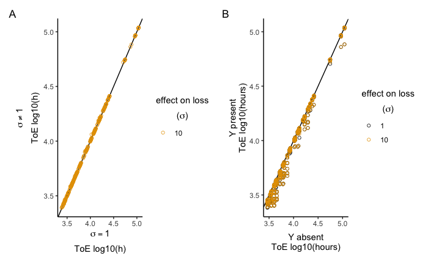

```r
# assembling and exporting figure 6
fig8 = p1 + p2
fig8
ggsave(plot = fig8, filename = '/Users/jga039/Documents/simulations/analysis/figures_tables/fig_06.tiff', width = 210, height = 148/2, units = 'mm', dpi = 300)
```

## Multiple effects analysis

### checking the contribution of the different interaction variables in singular models.

```r
# subsetting [cases of exctintion] to exclude the cases of "no interactions"  --> 3.7 Multiple interactions
only_interactions = singles_extinction[!(singles_extinction$epistasis == '0' & singles_extinction$intrafx1 == '1' & singles_extinction$interfx1 == '1' &
                                      singles_extinction$intrafx2 == '1' & singles_extinction$interfx2 == '1' & singles_extinction$lossxy == '1'),]

# subsetting [steady state, i.e. stable plasmids] to exclude the cases of "no interactions"  --> 3.7 Multiple interactions
only_interactions_steady = singles_steady_0[!(singles_steady_0$epistasis == '0' & singles_steady_0$intrafx1 == '1' & singles_steady_0$interfx1 == '1' &
                                      singles_steady_0$intrafx2 == '1' & singles_steady_0$interfx2 == '1' & singles_steady_0$lossxy == '1'),]
only_interactions_steady = only_interactions_steady[only_interactions_steady$X >= 1 | only_interactions_steady$XY >= 1,] # only cases where there is no exctinction
```

```r
print(paste('from a total of', (nrow(only_interactions) + nrow(only_interactions_steady)), 'cases, there is extinction for', nrow(only_interactions), 'cases, while in', nrow(only_interactions_steady), 'cases the plasmids are stable.'))
```

```
[1] "from a total of 5184 cases, there is extinction for 5056 cases, while in 128 cases the plasmids are stable."
```

```r
only_interactions['ratio_alone'] = only_interactions$X_XY / only_interactions$alone  # ratio against absence of competitor

# encoding variable as factor for further analyses
only_interactions['out_alone'] = ifelse(test = only_interactions$ratio_alone > 1, yes = 'increase', no = 'decrease'); only_interactions[only_interactions$ratio_alone == 1, 'out_alone'] = 'null'
table(only_interactions$out_alone)
```

```
decrease increase
    4685      371
```

```r
only_interactions[only_interactions$out_alone %in% c('decrease','null'),'out_alone'] = 'decrease/no effect'; table(only_interactions$out_alone)
```

```
decrease/no effect           increase
              4685                371
```

```r
# reshaping the data for further analysis
tmp = only_interactions[, c('epistasis','intrafx1','interfx1','intrafx2','interfx2','lossxy','out_alone')]
colnames(tmp) = c('ε','αx','ξx','αy','ξy','σ','out_alone')
tmp = melt(data = tmp, id.vars = 'out_alone')
```

```
attributes are not identical across measure variables; they will be dropped
```

```r
tmp = tmp[ !((tmp$variable == 'ε' & tmp$value == '0') | (tmp$variable %in% c('αx','ξx','αy','ξy','σ') & tmp$value == '1')) ,]
tmp2 = table(tmp$variable, tmp$out_alone)

x3 = data.frame('* groups displaying the same letter are not significantly different')  # note for letter meaning

# chi square test
x5 = chisq.test(x = tmp2, correct = T); x7 = as.data.frame(t(unlist(x5)))[c(4,2:3)]

# Fisher pairwise Nominal Independence test
res = pairwiseNominalIndependence(x = tmp2, fisher = T, gtest = F, chisq = T, correct = 'yates')
```

```
Chi-squared approximation may be incorrect
```

```r
# summarizing the stats of the qualitative analyses
x4 = as.data.frame.matrix(x5$observed); x4['interaction'] = rownames(x4)
x6 = as.data.frame(cldList(comparison = res$Comparison, p.value = res$p.adj.Fisher, threshold = .05))
for(i in x6$Group) { x4[i, "Fisher's exact test pairwise Nominal Independence*"] = x6[x6$Group == i, 'Letter']}
x4 = x4[,c('interaction',colnames(x4)[colnames(x4) != 'interaction'])]
x4['interaction_full_name'] = c('epistasis', 'intracellular interaction affecting conjugation of X', 'intercellular interaction affecting conjugation of X', 'intracellular interaction affecting conjugation of Y', 'intercellular interaction affecting conjugation of Y', 'interaction affecting loss')

# creating Supp.TableS14
addWorksheet(wb, sheetName = "Supp.TableS14")
writeData(wb, sheet = 14, x = x7, startCol = 1, startRow = 1, borders = 'surrounding')
writeData(wb, sheet = 14, x = x4, startCol = 1, startRow = (nrow(x2) + 2), borders = 'all')
writeData(wb, sheet = 14, x = x3, startCol = 1, startRow = (nrow(x7) + nrow(x4) + 3), colNames = F)

x7; x4; x3
```

```
                      method parameter.df               p.value
1 Pearson's Chi-squared test            5 6.02571401912614e-129
   interaction decrease/no effect increase Fisher's exact test pairwise Nominal Independence*                                interaction_full_name
ε            ε                893      275                                                  a                                            epistasis
αx          αx                818       46                                                  b intracellular interaction affecting conjugation of X
ξx          ξx                861        3                                                  c intercellular interaction affecting conjugation of X
αy          αy                843       21                                                  d intracellular interaction affecting conjugation of Y
ξy          ξy                838       26                                                  d intercellular interaction affecting conjugation of Y
σ            σ                432        0                                                  c                           interaction affecting loss
  X...groups.displaying.the.same.letter.are.not.significantly.different.
1    * groups displaying the same letter are not significantly different
```

```r
# reshaping data for plotting
tmp = only_interactions[, c('ratio_alone','epistasis','intrafx1','interfx1','intrafx2','interfx2','lossxy','out_alone')]
tmp = melt(data = tmp, id.vars = c('ratio_alone','out_alone'))
```

```
attributes are not identical across measure variables; they will be dropped
```

```r
tmp = tmp[ !((tmp$variable == 'epistasis' & tmp$value == '0') | (tmp$variable %in% c('intrafx1','interfx1','intrafx2','interfx2','lossxy') & tmp$value == '1')) ,]
tmp[tmp$variable == 'epistasis','var'] = 'epsilon'; tmp[tmp$variable == 'lossxy','var'] = 'sigma'
tmp[tmp$variable == 'intrafx1','var'] = 'alpha[X]'; tmp[tmp$variable == 'intrafx2','var'] = 'alpha[Y]'; tmp[tmp$variable == 'interfx1','var'] = 'xi[X]'; tmp[tmp$variable == 'interfx2','var'] = 'xi[Y]'
```

```r
# creating figure 7 panel A
p1 = ggplot(data = tmp[tmp$variable == 'epistasis',], mapping = aes(x = value, y = ratio_alone, color = out_alone)) +
  theme_classic() + labs(tag = 'A') + geom_point(position = 'jitter', shape = 21, fill = NA, alpha = 3/4) + facet_grid(.~var, scales = 'free', labeller = label_parsed) +
  xlab('') + ylab('Y present / Y absent\nlog10(hours)') + theme(strip.text = element_text(size = 11)) + scale_color_manual(values = my_palete[c(2:3)], name = '')

# creating figure 7 panel B
p2 = ggplot(data = tmp[tmp$variable != 'epistasis',], mapping = aes(x = value, y = ratio_alone, color = out_alone)) +
  theme_classic() + labs(tag = 'B') + geom_point(position = 'jitter', shape = 21, fill = NA, alpha = 3/4) + facet_grid(.~var, scales = 'free', labeller = label_parsed) + theme(axis.text.x = element_text(angle = 90)) +
  xlab('') + ylab('Y present / Y absent\nlog10(hours)') + theme(strip.text = element_text(size = 10)) + scale_color_manual(values = my_palete[c(2:3)], name = '')
```

```r
# assembling and exporting figure 7
p4 = ggarrange(p1, p2, ncol = 2, nrow = 1, common.legend = T, legend = 'bottom')
fig9 = p4
ggsave(plot = fig9, filename = '/Users/jga039/Documents/simulations/analysis/figures_tables/fig_07.tiff', width = 148, height = 210/2, units = 'mm', dpi = 300)
```

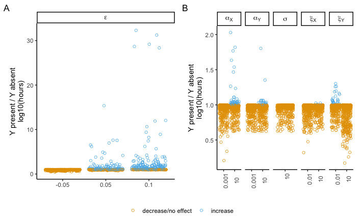

```r
fig9
```

```r
print('interactions allowing survival:')
```

```
[1] "interactions allowing survival:"
```

```r
only_interactions_steady['outcome'] = 'survived'
tmp = only_interactions_steady[, c('epistasis','intrafx1','interfx1','intrafx2','interfx2','lossxy','outcome')]
tmp = melt(data = tmp, id.vars = 'outcome')
```

```
attributes are not identical across measure variables; they will be dropped
```

```r
tmp = tmp[ !((tmp$variable == 'epistasis' & tmp$value == '0') | (tmp$variable %in% c('intrafx1','interfx1','intrafx2','interfx2','lossxy') & tmp$value == '1')) ,]
table(tmp$variable, tmp$outcome)
```

```
            survived
  epistasis      128
  intrafx1         0
  interfx1         0
  intrafx2         0
  interfx2         0
  lossxy           0
```

#### Importing the fixed competitor simulation output files

```r
# (i.e multiple interactions may occur, but the competitor plasmid is always the same)

# steady state data
fixed_steady_0 = read.table(file = '/Users/jga039/Documents/simulations/final_data/gama_steady_state_singles_fixed_competitor_REVIEW.txt')
fixed_steady_0['focal'] = apply(X = as.matrix(fixed_steady_0$ID), MARGIN = 1, FUN = function(x){
  paste(unlist(strsplit(x = unlist(strsplit(x = as.character(x), split = ':'))[1], split = '_'))[c(1,4,6)], collapse = '_') } )
fixed_steady_0['competitor'] = apply(X = as.matrix(fixed_steady_0$ID), MARGIN = 1, FUN = function(x){
  paste(unlist(strsplit(x = unlist(strsplit(x = as.character(x), split = ':'))[2], split = '_'))[c(1,4,6)], collapse = '_') } )
fixed_steady_0['competitor2'] = apply(X = as.matrix(fixed_steady_0$ID), MARGIN = 1, FUN = function(x){
  paste(unlist(strsplit(x = unlist(strsplit(x = as.character(x), split = ':'))[2], split = '_'))[c(1,4)], collapse = '_') } )
fixed_steady_0['loss'] = as.factor(apply(X = as.matrix(fixed_steady_0$ID), MARGIN = 1, FUN = function(x){ unlist(strsplit(x = as.character(x), split = '_'))[12] } ))
fixed_steady_0['epistasis'] = as.factor(apply(X = as.matrix(fixed_steady_0$ID), MARGIN = 1, FUN = function(x){ unlist(strsplit(x = as.character(x), split = '_'))[11] } ))
fixed_steady_0['intrafx1'] = as.factor(apply(X = as.matrix(fixed_steady_0$ID), MARGIN = 1, FUN = function(x){ unlist(strsplit(x = as.character(x), split = '_'))[2] } ))
fixed_steady_0['interfx1'] = as.factor(apply(X = as.matrix(fixed_steady_0$ID), MARGIN = 1, FUN = function(x){ unlist(strsplit(x = as.character(x), split = '_'))[3] } ))
fixed_steady_0['intrafx2'] = as.factor(apply(X = as.matrix(fixed_steady_0$ID), MARGIN = 1, FUN = function(x){ unlist(strsplit(x = as.character(x), split = '_'))[8] } ))
fixed_steady_0['interfx2'] = as.factor(apply(X = as.matrix(fixed_steady_0$ID), MARGIN = 1, FUN = function(x){ unlist(strsplit(x = as.character(x), split = '_'))[9] } ))
fixed_steady_0['lossxy'] = as.factor(apply(X = as.matrix(fixed_steady_0$ID), MARGIN = 1, FUN = function(x){ unlist(strsplit(x = as.character(x), split = '_'))[13] } ))
fixed_steady_0['fitness'] = as.factor(apply(X = as.matrix(fixed_steady_0$focal), MARGIN = 1, FUN = function(x) { as.numeric(unlist(strsplit(x = x, split = '_'))[2]) }))
fixed_steady_0['conjugation'] = as.factor(apply(X = as.matrix(fixed_steady_0$focal), MARGIN = 1, FUN = function(x) { as.numeric(unlist(strsplit(x = x, split = '_'))[1]) }))
fixed_steady_0['fitness2'] = as.factor(apply(X = as.matrix(fixed_steady_0$competitor), MARGIN = 1, FUN = function(x) { as.numeric(unlist(strsplit(x = x, split = '_'))[2]) }))
fixed_steady_0['conjugation2'] = as.factor(apply(X = as.matrix(fixed_steady_0$competitor), MARGIN = 1, FUN = function(x) { as.numeric(unlist(strsplit(x = x, split = '_'))[1]) }))

# time to extinction data
fixed_extinction = read.table(file = '/Users/jga039/Documents/simulations/final_data/gama_time_to_extinction_singles_fixed_competitor_REVIEW.txt')
fixed_extinction['focal'] = apply(X = as.matrix(fixed_extinction$ID), MARGIN = 1, FUN = function(x){
  paste(unlist(strsplit(x = unlist(strsplit(x = as.character(x), split = ':'))[1], split = '_'))[c(1,4,6)], collapse = '_') } )
fixed_extinction['competitor'] = apply(X = as.matrix(fixed_extinction$ID), MARGIN = 1, FUN = function(x){
  paste(unlist(strsplit(x = unlist(strsplit(x = as.character(x), split = ':'))[2], split = '_'))[c(1,4,6)], collapse = '_') } )
fixed_extinction['competitor2'] = apply(X = as.matrix(fixed_extinction$ID), MARGIN = 1, FUN = function(x){
  paste(unlist(strsplit(x = unlist(strsplit(x = as.character(x), split = ':'))[2], split = '_'))[c(1,4)], collapse = '_') } )
fixed_extinction['loss'] = as.factor(apply(X = as.matrix(fixed_extinction$ID), MARGIN = 1, FUN = function(x){ unlist(strsplit(x = as.character(x), split = '_'))[12] } ))
fixed_extinction['epistasis'] = as.factor(apply(X = as.matrix(fixed_extinction$ID), MARGIN = 1, FUN = function(x){ unlist(strsplit(x = as.character(x), split = '_'))[11] } ))
fixed_extinction['intrafx1'] = as.factor(apply(X = as.matrix(fixed_extinction$ID), MARGIN = 1, FUN = function(x){ unlist(strsplit(x = as.character(x), split = '_'))[2] } ))
fixed_extinction['interfx1'] = as.factor(apply(X = as.matrix(fixed_extinction$ID), MARGIN = 1, FUN = function(x){ unlist(strsplit(x = as.character(x), split = '_'))[3] } ))
fixed_extinction['intrafx2'] = as.factor(apply(X = as.matrix(fixed_extinction$ID), MARGIN = 1, FUN = function(x){ unlist(strsplit(x = as.character(x), split = '_'))[8] } ))
fixed_extinction['interfx2'] = as.factor(apply(X = as.matrix(fixed_extinction$ID), MARGIN = 1, FUN = function(x){ unlist(strsplit(x = as.character(x), split = '_'))[9] } ))
fixed_extinction['lossxy'] = as.factor(apply(X = as.matrix(fixed_extinction$ID), MARGIN = 1, FUN = function(x){ unlist(strsplit(x = as.character(x), split = '_'))[13] } ))
fixed_extinction['fitness'] = as.factor(apply(X = as.matrix(fixed_extinction$focal), MARGIN = 1, FUN = function(x) { as.numeric(unlist(strsplit(x = x, split = '_'))[2]) }))
fixed_extinction['conjugation'] = as.factor(apply(X = as.matrix(fixed_extinction$focal), MARGIN = 1, FUN = function(x) { as.numeric(unlist(strsplit(x = x, split = '_'))[1]) }))
fixed_extinction['fitness2'] = as.factor(apply(X = as.matrix(fixed_extinction$competitor), MARGIN = 1, FUN = function(x) { as.numeric(unlist(strsplit(x = x, split = '_'))[2]) }))
fixed_extinction['conjugation2'] = as.factor(apply(X = as.matrix(fixed_extinction$competitor), MARGIN = 1, FUN = function(x) { as.numeric(unlist(strsplit(x = x, split = '_'))[1]) }))
fixed_extinction['alone'] = apply(X = as.matrix(fixed_extinction$focal), MARGIN = 1, FUN = function(x) { solo_extinction[solo_extinction$focal == x, 'X']})
fixed_extinction['no_interaction'] = apply(X = fixed_extinction, MARGIN = 1, FUN = function(x) {
  fixed_extinction[ fixed_extinction$focal == x['focal'] & fixed_extinction$competitor == x['competitor'] &
                 fixed_extinction$epistasis == '0' & fixed_extinction$intrafx1 == '1' & fixed_extinction$interfx1 == '1' &
                 fixed_extinction$intrafx2 == '1' & fixed_extinction$interfx2 == '1' & fixed_extinction$lossxy == '1', 'X_XY']})
```

### checking the contribution of the different interaction variables in multiple-interaction models.

```r
fixed_steady = fixed_steady_0[fixed_steady_0$X >= 1 | fixed_steady_0$XY >= 1, ]
print(paste('X does not go to extinction in', nrow(fixed_steady), 'out of', nrow(fixed_steady_0), 'thus in', round(100 * nrow(fixed_steady) / nrow(fixed_steady_0), digits = 2), '% and X only cells are present in', nrow(fixed_steady[fixed_steady$X >= 1,]), 'and XY cells are present in', nrow(fixed_steady[fixed_steady$XY >= 1,])))
```

```
[1] "X does not go to extinction in 291 out of 23328 thus in 1.25 % and X only cells are present in 291 and XY cells are present in 291"
```

```r
print(paste('among these', nrow(fixed_steady), 'Y is present in', nrow(fixed_steady[fixed_steady$Y >= 1,]), 'and XY is present in', nrow(fixed_steady[fixed_steady$XY >= 1,])))
```

```
[1] "among these 291 Y is present in 291 and XY is present in 291"
```

```r
print(paste('Y does not go to extinction in', nrow(fixed_steady_0[fixed_steady_0$Y >= 1 & fixed_steady_0$X < 1,]), 'of the cases where X gets extinct, and XY does not got to extinction in', nrow(fixed_steady_0[fixed_steady_0$XY >= 1 & fixed_steady_0$X < 1,]), 'of the same subset.'))
```

```
[1] "Y does not go to extinction in 0 of the cases where X gets extinct, and XY does not got to extinction in 0 of the same subset."
```

```r
print(paste('X does not go to extinction in', nrow(solo_steady_0[solo_steady_0$X >= 1,]), 'when alone.'))
```

```
[1] "X does not go to extinction in 0 when alone."
```

```r
fixed_steady['fit_XY'] = as.numeric(as.character(fixed_steady$fitness)) * as.numeric(as.character(fixed_steady$fitness2)) + as.numeric(as.character(fixed_steady$epistasis))
print(paste('number of cases where fit X > fit XY:',nrow(fixed_steady[as.numeric(as.character(fixed_steady$fitness)) > as.numeric(as.character(fixed_steady$fit_XY)),])))
```

```
[1] "number of cases where fit X > fit XY: 0"
```

Thus in 291 cases out of 23328 X does not go extinct. These are exactly the same cases where Y and XY can persist.

```r
print('distribution of cases of survival per variable:')
```

```
[1] "distribution of cases of survival per variable:"
```

```r
fixed_steady_0['survival'] = ifelse(test = fixed_steady_0$X >= 1 | fixed_steady_0$XY >= 1, yes = 'survival', no = 'extinction')
list(fitness_distribution = table(fixed_steady_0$fitness, fixed_steady_0$survival), conjugation_distribution = table(fixed_steady_0$conjugation, fixed_steady_0$survival),
     loss_distribution = table(fixed_steady_0$loss, fixed_steady_0$survival), epistasis_distribution = table(fixed_steady_0$epistasis, fixed_steady_0$survival),
     intrafx1_distribution = table(fixed_steady_0$intrafx1, fixed_steady_0$survival), intrafx2_distribution = table(fixed_steady_0$intrafx2, fixed_steady_0$survival),
     interfx1_distribution = table(fixed_steady_0$interfx1, fixed_steady_0$survival), interfx2_distribution = table(fixed_steady_0$interfx2, fixed_steady_0$survival),
     lossXY_distribution = table(fixed_steady_0$lossxy, fixed_steady_0$survival))
```

```
$fitness_distribution

        extinction survival
  0.85        5832        0
  0.9         5748       84
  0.95        5736       96
  0.975       5721      111

$conjugation_distribution

        extinction survival
  1e-13       7776        0
  1e-12       7776        0
  1e-11       7485      291

$loss_distribution

        extinction survival
  1e-04       7765       11
  1e-06       7640      136
  1e-08       7632      144

$epistasis_distribution

        extinction survival
  -0.05       5832        0
  0           5832        0
  0.05        5832        0
  0.1         5541      291

$intrafx1_distribution

        extinction survival
  0.001       7776        0
  1           7776        0
  10          7485      291

$intrafx2_distribution

        extinction survival
```

[output cut: 8 more lines]

```
  1          7667      109
  10         7658      118

$interfx2_distribution

       extinction survival
  0.01       7691       85
  1          7683       93
  10         7663      113

$lossXY_distribution

     extinction survival
  1       11513      151
  10      11524      140
```

Thus all surviving X plasmids have conjugation of 1e-11, epistasis of 0.1 and facilitation (intrafx1 = 10) and fitness > .85.

```r
print(paste('plasmid-free cells go to extinction in',nrow(fixed_steady[fixed_steady$O < 1,]), 'cases out of',nrow(fixed_steady)))
```

```
[1] "plasmid-free cells go to extinction in 144 cases out of 291"
```

```r
tmp = fixed_steady; tmp['plasmid_free'] = ifelse(test = tmp$O >= 1, yes = 'yes', no = 'no'); tmp$O = ifelse(test = tmp$O >= 1, yes = tmp$O, no = 0)
tmp['dom'] = ifelse(test = tmp$XY > tmp$X, yes = 'XY', no = 'X')
tmp['total'] = tmp$O + tmp$X + tmp$Y + tmp$XY; tmp['freqX'] = 100 * (tmp$X / tmp$total); tmp['freqXY'] = 100 * (tmp$XY / tmp$total); tmp['freqY'] = 100 * (tmp$Y / tmp$total)
print(paste('the maximum frequency Y cells can attain is',max(tmp$freqY)))
```

```
[1] "the maximum frequency Y cells can attain is 0.946572229441725"
```

```r
print('distribution of presence of plasmid-free cells per value of loss:'); table(tmp$plasmid_free,tmp$loss)
```

```
[1] "distribution of presence of plasmid-free cells per value of loss:"

      1e-04 1e-06 1e-08
  no      0     0   144
  yes    11   136     0
```

Plasmid-free cells wont be present when loss = -8.

### Cases that go to extinction

```r
fixed_extinction['ratio_alone'] = fixed_extinction$X_XY / fixed_extinction$alone  # ratio against absence of competitor

# encoding variable as factor for further analyses
fixed_extinction['out_alone'] = ifelse(test = fixed_extinction$ratio_alone > 1, yes = 'increase', no = 'decrease'); fixed_extinction[fixed_extinction$ratio_alone == 1, 'out_alone'] = 'null'

# displaying the distribution
table(fixed_extinction$out_alone)
```

```
decrease increase     null
   19811     3222        4
```

```r
fixed_extinction[fixed_extinction$out_alone %in% c('decrease','null'),'out_alone'] = 'decrease_null'; table(fixed_extinction$out_alone)
```

```
decrease_null      increase
        19815          3222
```

```r
print('checking if any of the variables alone can explain the results')
```

```
[1] "checking if any of the variables alone can explain the results"
```

```r
list(fitness_distribution = table(fixed_extinction$fitness, fixed_extinction$out_alone), conjugation_distribution = table(fixed_extinction$conjugation, fixed_extinction$out_alone),
     loss_distribution = table(fixed_extinction$loss, fixed_extinction$out_alone), epistasis_distribution = table(fixed_extinction$epistasis, fixed_extinction$out_alone),
     intrafx1_distribution = table(fixed_extinction$intrafx1, fixed_extinction$out_alone), intrafx2_distribution = table(fixed_extinction$intrafx2, fixed_extinction$out_alone),
     interfx1_distribution = table(fixed_extinction$interfx1, fixed_extinction$out_alone), interfx2_distribution = table(fixed_extinction$interfx2, fixed_extinction$out_alone),
     lossXY_distribution = table(fixed_extinction$lossxy, fixed_extinction$out_alone))
```

```
$fitness_distribution

        decrease_null increase
  0.85           5010      822
  0.9            4959      789
  0.95           4973      763
  0.975          4873      848

$conjugation_distribution

        decrease_null increase
  1e-13          7168      608
  1e-12          6784      992
  1e-11          5863     1622

$loss_distribution

        decrease_null increase
  1e-04          7065      700
  1e-06          6474     1166
  1e-08          6276     1356

$epistasis_distribution

        decrease_null increase
  -0.05          5616      216
  0              5616      216
  0.05           5437      395
  0.1            3146     2395

$intrafx1_distribution

        decrease_null increase
  0.001          7331      445
  1              6832      944
  10             5652     1833

$intrafx2_distribution

        decrease_null increase
```

[output cut: 8 more lines]

```
  1             6760      907
  10            5928     1730

$interfx2_distribution

       decrease_null increase
  0.01          6960      731
  1             6737      946
  10            6118     1545

$lossXY_distribution

     decrease_null increase
  1           9789     1724
  10         10026     1498
```

None of the variables clearly explains the outcome.

```r
# reshaping data to perform the logistic regression
tmp = fixed_extinction[, c('epistasis','intrafx1','interfx1','interfx2','intrafx2','lossxy','out_alone')]
colnames(tmp) = c('ε','αx','ξx','ξy','αy','σ','out_alone')
for(i in colnames(tmp)[1:(length(colnames(tmp))-1)]) { tmp[,i] = as.numeric(as.character(tmp[,i])) }
tmp$out_alone = factor(x = tmp$out_alone, levels = c('decrease_null','increase') ,ordered = T)

# running logistic regression (FULL) model
model = glm(formula = out_alone ~.,family = binomial(link = 'logit'), data = tmp)
x2 = as.data.frame(summary(model)$coefficients); rownames(x2)[1] = 'NULL'
x3 = as.data.frame(anova(model, test="Chisq"))[,c('Df','Deviance','Resid. Dev')]
x2 = cbind(x2,x3); x2[nrow(x2),'AIC'] = summary(model)$aic; x2
```

```
        Estimate  Std. Error    z value      Pr(>|z|) Df   Deviance Resid. Dev      AIC
NULL -5.76321792 0.091543812 -62.955844  0.000000e+00 NA         NA   18646.74       NA
ε    34.26015538 0.667895214  51.295704  0.000000e+00  1 3897.72053   14749.02       NA
αx    0.20621147 0.005405969  38.145141  0.000000e+00  1 1431.57780   13317.44       NA
ξx    0.16422214 0.005241145  31.333254 1.645261e-215  1 1007.25019   12310.19       NA
ξy    0.12079530 0.005171525  23.357773 1.148997e-120  1  558.63975   11751.55       NA
αy    0.03417250 0.005177032   6.600790  4.089720e-11  1   43.12380   11708.43       NA
σ    -0.02919325 0.005263760  -5.546083  2.921409e-08  1   30.88306   11677.54 11691.54
```

```r
x2[nrow(x2),'cumulative Cragg & Uhler pseudoR2'] = pR2(model)['r2CU']; x2[nrow(x2),'cumulative Tjur pseudoR2']= r2_tjur(model); x2
```

```
fitting null model for pseudo-r2
        Estimate  Std. Error    z value      Pr(>|z|) Df   Deviance Resid. Dev      AIC cumulative Cragg & Uhler pseudoR2 cumulative Tjur pseudoR2
NULL -5.76321792 0.091543812 -62.955844  0.000000e+00 NA         NA   18646.74       NA                                NA                       NA
ε    34.26015538 0.667895214  51.295704  0.000000e+00  1 3897.72053   14749.02       NA                                NA                       NA
αx    0.20621147 0.005405969  38.145141  0.000000e+00  1 1431.57780   13317.44       NA                                NA                       NA
ξx    0.16422214 0.005241145  31.333254 1.645261e-215  1 1007.25019   12310.19       NA                                NA                       NA
ξy    0.12079530 0.005171525  23.357773 1.148997e-120  1  558.63975   11751.55       NA                                NA                       NA
αy    0.03417250 0.005177032   6.600790  4.089720e-11  1   43.12380   11708.43       NA                                NA                       NA
σ    -0.02919325 0.005263760  -5.546083  2.921409e-08  1   30.88306   11677.54 11691.54                         0.4704524                0.3471915
```

```r
# adding individual and cumulative coefficients to the supp table
model = glm(formula = out_alone ~ ε,family = binomial(link = 'logit'), data = tmp)
x2['ε','AIC'] = summary(model)$aic
x2['ε','cumulative Cragg & Uhler pseudoR2'] = x2['ε','individual Cragg & Uhler pseudoR2'] = pR2(model)['r2CU']
```

```
fitting null model for pseudo-r2
```

```r
x2['ε','cumulative Tjur pseudoR2'] = x2['ε','individual Tjur pseudoR2'] = r2_tjur(model)

model = glm(formula = out_alone ~ ε + αx,family = binomial(link = 'logit'), data = tmp)
x2['αx','AIC'] = summary(model)$aic; x2['αx','cumulative Cragg & Uhler pseudoR2'] = pR2(model)['r2CU']; x2['αx','cumulative Tjur pseudoR2'] = r2_tjur(model)
```

```
fitting null model for pseudo-r2
```

```r
model = glm(formula = out_alone ~ ε + αx + ξx,family = binomial(link = 'logit'), data = tmp)
x2['ξx','AIC'] = summary(model)$aic; x2['ξx','cumulative Cragg & Uhler pseudoR2'] = pR2(model)['r2CU']; x2['ξx','cumulative Tjur pseudoR2'] = r2_tjur(model)
```

```
fitting null model for pseudo-r2
```

```r
model = glm(formula = out_alone ~ ε + αx + ξx + ξy,family = binomial(link = 'logit'), data = tmp)
x2['ξy','AIC'] = summary(model)$aic; x2['ξy','cumulative Cragg & Uhler pseudoR2'] = pR2(model)['r2CU']; x2['ξy','cumulative Tjur pseudoR2'] = r2_tjur(model)
```

```
fitting null model for pseudo-r2
```

```r
model = glm(formula = out_alone ~ ε + αx + ξx + ξy + αy,family = binomial(link = 'logit'), data = tmp)
x2['αy','AIC'] = summary(model)$aic; x2['αy','cumulative Cragg & Uhler pseudoR2'] = pR2(model)['r2CU']; x2['αy','cumulative Tjur pseudoR2'] = r2_tjur(model)
```

```
fitting null model for pseudo-r2
```

```r
model = glm(formula = out_alone ~ αx,family = binomial(link = 'logit'), data = tmp)
x2['αx','AIC'] = summary(model)$aic; x2['αx','individual Cragg & Uhler pseudoR2'] = pR2(model)['r2CU']; x2['αx','individual Tjur pseudoR2'] = r2_tjur(model)
```

```
fitting null model for pseudo-r2
```

```r
model = glm(formula = out_alone ~ ξx,family = binomial(link = 'logit'), data = tmp)
x2['ξx','AIC'] = summary(model)$aic; x2['ξx','individual Cragg & Uhler pseudoR2'] = pR2(model)['r2CU']; x2['ξx','individual Tjur pseudoR2'] = r2_tjur(model)
```

```
fitting null model for pseudo-r2
```

```r
model = glm(formula = out_alone ~ ξy,family = binomial(link = 'logit'), data = tmp)
x2['ξy','AIC'] = summary(model)$aic; x2['ξy','individual Cragg & Uhler pseudoR2'] = pR2(model)['r2CU']; x2['ξy','individual Tjur pseudoR2'] = r2_tjur(model)
```

```
fitting null model for pseudo-r2
```

```r
model = glm(formula = out_alone ~ αy,family = binomial(link = 'logit'), data = tmp)
x2['αy','AIC'] = summary(model)$aic; x2['αy','individual Cragg & Uhler pseudoR2'] = pR2(model)['r2CU']; x2['αy','individual Tjur pseudoR2'] = r2_tjur(model)
```

```
fitting null model for pseudo-r2
```

```r
model = glm(formula = out_alone ~ σ,family = binomial(link = 'logit'), data = tmp)
x2['σ','AIC'] = summary(model)$aic; x2['σ','individual Cragg & Uhler pseudoR2'] = pR2(model)['r2CU']; x2['σ','individual Tjur pseudoR2'] = r2_tjur(model)
```

```
fitting null model for pseudo-r2
```

```r
x2['interaction_full_name'] = c('','epistasis', 'intracellular interaction affecting conjugation of X', 'intercellular interaction affecting conjugation of X', 'intercellular interaction affecting conjugation of Y', 'intracellular interaction affecting conjugation of Y', 'interaction affecting loss')
```

```r
# creating Supp.TableS15
x2
```

```
        Estimate  Std. Error    z value      Pr(>|z|) Df   Deviance Resid. Dev      AIC cumulative Cragg & Uhler pseudoR2 cumulative Tjur pseudoR2
NULL -5.76321792 0.091543812 -62.955844  0.000000e+00 NA         NA   18646.74       NA                                NA                       NA
ε    34.26015538 0.667895214  51.295704  0.000000e+00  1 3897.72053   14749.02 14753.02                         0.2805166                0.1905082
αx    0.20621147 0.005405969  38.145141  0.000000e+00  1 1431.57780   13317.44 17639.12                         0.3721979                0.2571940
ξx    0.16422214 0.005241145  31.333254 1.645261e-215  1 1007.25019   12310.19 17952.11                         0.4333737                0.3069832
ξy    0.12079530 0.005171525  23.357773 1.148997e-120  1  558.63975   11751.55 18288.54                         0.4661674                0.3422492
αy    0.03417250 0.005177032   6.600790  4.089720e-11  1   43.12380   11708.43 18623.89                         0.4686660                0.3451631
σ    -0.02919325 0.005263760  -5.546083  2.921409e-08  1   30.88306   11677.54 18632.04                         0.4704524                0.3471915
     individual Cragg & Uhler pseudoR2 individual Tjur pseudoR2                                interaction_full_name
NULL                                NA                       NA
ε                          0.280516638             0.1905082313                                            epistasis
αx                         0.077425668             0.0462996745 intracellular interaction affecting conjugation of X
ξx                         0.053832580             0.0318091351 intercellular interaction affecting conjugation of X
ξy                         0.028113099             0.0163674981 intercellular interaction affecting conjugation of Y
αy                         0.002099222             0.0011820607 intracellular interaction affecting conjugation of Y
σ                          0.001461888             0.0008109428                           interaction affecting loss
```

```r
addWorksheet(wb, sheetName = "Supp.TableS15")
writeData(wb, sheet = 15, x = x2, startCol = 1, startRow = 1, borders = 'all', rowNames = T)
```

all variables are important. The chi-square of 6969.195 (difference in deviance) with 6 degrees of freedom and an associated p-value of less than 0.001 tells us that our model as a whole fits significantly better than an empty model. Models explains 34.71915 % - 47.04524 % of variance. (((The log-likelihood from the fitted model; The log-likelihood from the intercept-only restricted model; Minus two times the difference in the log-likelihoods; McFadden’s pseudo r-squared; Maximum likelihood pseudo r-squared AKA Cox & Snell; Cragg and Uhler’s pseudo r-squared AKA Nagelkerke)))

### Cases that don’t go to extinction

```r
# subsetting conditions that allow survival (i.e. all cases where ε = 0.1, αX = 10, γX = 10-11and ωX > 0.85)
essential_conditions =
  fixed_steady_0[fixed_steady_0$epistasis == '0.1' & fixed_steady_0$conjugation == '1e-11' & fixed_steady_0$intrafx1 == '10' & (fixed_steady_0$fitness %in% c('0.9','0.95','0.975')), ]
print(paste('there is a total of cases fulfilling the conditions for survival:', nrow(essential_conditions), ', and there is survival in:', round(100 * (nrow(fixed_steady) / nrow(essential_conditions)), digits = 2), '%, as:'))
```

```
[1] "there is a total of cases fulfilling the conditions for survival: 486 , and there is survival in: 59.88 %, as:"
```

```r
table(essential_conditions$survival)
```

```
extinction   survival
       195        291
```

```r
print('distribution of survival outcome per variable')
```

```
[1] "distribution of survival outcome per variable"
```

```r
list(fitness_distribution = table(essential_conditions$fitness, essential_conditions$survival), loss_distribution = table(essential_conditions$loss, essential_conditions$survival),
     intrafx2_distribution = table(essential_conditions$intrafx2, essential_conditions$survival), interfx1_distribution = table(essential_conditions$interfx1,essential_conditions$survival),
     interfx2_distribution = table(essential_conditions$interfx2, essential_conditions$survival), lossxy_distribution = table(essential_conditions$lossxy, essential_conditions$survival))
```

```
$fitness_distribution

        extinction survival
  0.85           0        0
  0.9           78       84
  0.95          66       96
  0.975         51      111

$loss_distribution

        extinction survival
  1e-04        151       11
  1e-06         26      136
  1e-08         18      144

$intrafx2_distribution

        extinction survival
  0.001         70       92
  1             64       98
  10            61      101

$interfx1_distribution

       extinction survival
  0.01         98       64
  1            53      109
  10           44      118

$interfx2_distribution

       extinction survival
  0.01         77       85
  1            69       93
  10           49      113

$lossxy_distribution

     extinction survival
  1          92      151
  10        103      140
```

```r
# reshaping data to perform the logistic regression
tmp = essential_conditions[, c('interfx1','interfx2','lossxy','intrafx2','survival')]
colnames(tmp) = c('ξx','ξy','σ','αy','survival')
for(i in colnames(tmp)[1:(length(colnames(tmp))-1)]) { tmp[,i] = as.numeric(as.character(tmp[,i])) }
tmp$survival = factor(x = tmp$survival, levels = c('extinction','survival') ,ordered = T)

# running logistic regression (FULL) model
model = glm(formula = survival ~.,family = binomial(link = 'logit'), data = tmp)
x2 = as.data.frame(summary(model)$coefficients); rownames(x2)[1] = 'NULL'
x3 = as.data.frame(anova(model, test="Chisq"))[,c('Df','Deviance','Resid. Dev')]
x2 = cbind(x2,x3); x2[nrow(x2),'AIC'] = summary(model)$aic; x2
```

```
        Estimate Std. Error    z value     Pr(>|z|) Df   Deviance Resid. Dev      AIC
NULL -0.14494828 0.19996676 -0.7248619 4.685368e-01 NA         NA   654.6508       NA
ξx    0.10206500 0.02243265  4.5498419 5.368623e-06  1 21.5299904   633.1208       NA
ξy    0.07164410 0.02195771  3.2628216 1.103089e-03  1 10.9757176   622.1451       NA
σ    -0.02243861 0.02131359 -1.0527843 2.924399e-01  1  1.1083440   621.0368       NA
αy    0.01871093 0.02143543  0.8728972 3.827191e-01  1  0.7654739   620.2713 630.2713
```

```r
x2[nrow(x2),'cumulative Cragg & Uhler pseudoR2'] = pR2(model)['r2CU']; x2[nrow(x2),'cumulative Tjur pseudoR2']= r2_tjur(model); x2
```

```
fitting null model for pseudo-r2
        Estimate Std. Error    z value     Pr(>|z|) Df   Deviance Resid. Dev      AIC cumulative Cragg & Uhler pseudoR2 cumulative Tjur pseudoR2
NULL -0.14494828 0.19996676 -0.7248619 4.685368e-01 NA         NA   654.6508       NA                                NA                       NA
ξx    0.10206500 0.02243265  4.5498419 5.368623e-06  1 21.5299904   633.1208       NA                                NA                       NA
ξy    0.07164410 0.02195771  3.2628216 1.103089e-03  1 10.9757176   622.1451       NA                                NA                       NA
σ    -0.02243861 0.02131359 -1.0527843 2.924399e-01  1  1.1083440   621.0368       NA                                NA                       NA
αy    0.01871093 0.02143543  0.8728972 3.827191e-01  1  0.7654739   620.2713 630.2713                        0.09229326                0.0694795
```

```r
# adding individual and cumulative coefficients to the supp table
model = glm(formula = survival ~ ξx,family = binomial(link = 'logit'), data = tmp)
x2['ξx','AIC'] = summary(model)$aic
x2['ξx','cumulative Cragg & Uhler pseudoR2'] = x2['ξx','individual Cragg & Uhler pseudoR2'] = pR2(model)['r2CU']
```

```
fitting null model for pseudo-r2
```

```r
x2['ξx','cumulative Tjur pseudoR2'] = x2['ξx','individual Tjur pseudoR2'] = r2_tjur(model)

model = glm(formula = survival ~ ξx + ξy,family = binomial(link = 'logit'), data = tmp)
x2['ξy','AIC'] = summary(model)$aic; x2['ξy','cumulative Cragg & Uhler pseudoR2'] = pR2(model)['r2CU']; x2['ξy','cumulative Tjur pseudoR2'] = r2_tjur(model)
```

```
fitting null model for pseudo-r2
```

```r
model = glm(formula = survival ~ ξx + ξy + σ,family = binomial(link = 'logit'), data = tmp)
x2['σ','AIC'] = summary(model)$aic; x2['σ','cumulative Cragg & Uhler pseudoR2'] = pR2(model)['r2CU']; x2['σ','cumulative Tjur pseudoR2'] = r2_tjur(model)
```

```
fitting null model for pseudo-r2
```

```r
model = glm(formula = survival ~ ξy,family = binomial(link = 'logit'), data = tmp)
x2['ξy','AIC'] = summary(model)$aic; x2['ξy','individual Cragg & Uhler pseudoR2'] = pR2(model)['r2CU']; x2['ξy','individual Tjur pseudoR2'] = r2_tjur(model)
```

```
fitting null model for pseudo-r2
```

```r
model = glm(formula = survival ~ αy,family = binomial(link = 'logit'), data = tmp)
x2['αy','AIC'] = summary(model)$aic; x2['αy','individual Cragg & Uhler pseudoR2'] = pR2(model)['r2CU']; x2['αy','individual Tjur pseudoR2'] = r2_tjur(model)
```

```
fitting null model for pseudo-r2
```

```r
model = glm(formula = survival ~ σ,family = binomial(link = 'logit'), data = tmp)
x2['σ','AIC'] = summary(model)$aic; x2['σ','individual Cragg & Uhler pseudoR2'] = pR2(model)['r2CU']; x2['σ','individual Tjur pseudoR2'] = r2_tjur(model)
```

```
fitting null model for pseudo-r2
```

```r
x2['interaction_full_name'] = c('', 'intercellular interaction affecting conjugation of X', 'intercellular interaction affecting conjugation of Y', 'interaction affecting loss', 'intracellular interaction affecting conjugation of Y')
```

```r
# creating Supp.TableS17
x2
```

```
        Estimate Std. Error    z value     Pr(>|z|) Df   Deviance Resid. Dev      AIC cumulative Cragg & Uhler pseudoR2 cumulative Tjur pseudoR2
NULL -0.14494828 0.19996676 -0.7248619 4.685368e-01 NA         NA   654.6508       NA                                NA                       NA
ξx    0.10206500 0.02243265  4.5498419 5.368623e-06  1 21.5299904   633.1208 637.1208                        0.05855987               0.04326406
ξy    0.07164410 0.02195771  3.2628216 1.103089e-03  1 10.9757176   622.1451 648.1406                        0.08742937               0.06639856
σ    -0.02243861 0.02131359 -1.0527843 2.924399e-01  1  1.1083440   621.0368 657.6141                        0.09030857               0.06817785
αy    0.01871093 0.02143543  0.8728972 3.827191e-01  1  0.7654739   620.2713 657.9362                        0.09229326               0.06947950
     individual Cragg & Uhler pseudoR2 individual Tjur pseudoR2                                interaction_full_name
NULL                                NA                       NA
ξx                         0.058559873              0.043264060 intercellular interaction affecting conjugation of X
ξy                         0.028911020              0.021224917 intercellular interaction affecting conjugation of Y
σ                          0.002879725              0.002132346                           interaction affecting loss
αy                         0.001985730              0.001466294 intracellular interaction affecting conjugation of Y
```

```r
addWorksheet(wb, sheetName = "Supp.TableS16")
addWorksheet(wb, sheetName = "Supp.TableS17")
writeData(wb, sheet = 17, x = x2, startCol = 1, startRow = 1, borders = 'all', rowNames = T)
```

Only interfx1 and interfx2 are significant. The chi-square of 34.37953 (difference in deviance) with 4 degrees of freedom and an associated p-value of less than 0.001 tells us that our model as a whole fits significantly better than an empty model. Models explains 6.947950 % - 9.229326 % of variance. (((The log-likelihood from the fitted model; The log-likelihood from the intercept-only restricted model; Minus two times the difference in the log-likelihoods; McFadden’s pseudo r-squared; Maximum likelihood pseudo r-squared; Cragg and Uhler’s pseudo r-squared))) wtf no eta for lossxy?

#### considering survival as extended time (thus including the cases of survival)

```r
fixed_steady_0['outcome'] = 'increase'
fixed_steady_0[ fixed_steady_0$ID %in% fixed_extinction[fixed_extinction$out_alone != 'increase', 'ID'], 'outcome'] = 'decrease_null'
table(fixed_steady_0$outcome)
```

```
decrease_null      increase
        19815          3513
```

```r
# reshaping data to perform the logistic regression
tmp = fixed_steady_0[, c('epistasis','intrafx1','interfx1','interfx2','intrafx2','lossxy','outcome')]
colnames(tmp) = c('ε','αx','ξx','ξy','αy','σ','outcome')
for(i in colnames(tmp)[1:(length(colnames(tmp))-1)]) { tmp[,i] = as.numeric(as.character(tmp[,i])) }
tmp$outcome = factor(x = tmp$outcome, levels = c('decrease_null','increase') ,ordered = T)

# running logistic regression (FULL) model
model = glm(formula = outcome ~.,family = binomial(link = 'logit'), data = tmp)
x2 = as.data.frame(summary(model)$coefficients); rownames(x2)[1] = 'NULL'
x3 = as.data.frame(anova(model, test="Chisq"))[,c('Df','Deviance','Resid. Dev')]
x2 = cbind(x2,x3); x2[nrow(x2),'AIC'] = summary(model)$aic; x2
```

```
        Estimate  Std. Error    z value      Pr(>|z|) Df   Deviance Resid. Dev      AIC
NULL -5.87755922 0.091972234 -63.905800  0.000000e+00 NA         NA   19769.73       NA
ε    35.69072739 0.671112256  53.181457  0.000000e+00  1 4480.13609   15289.59       NA
αx    0.21982644 0.005346551  41.115561  0.000000e+00  1 1739.18760   13550.40       NA
ξx    0.16338800 0.005206759  31.379982 3.795326e-216  1 1010.69922   12539.70       NA
ξy    0.12016447 0.005130927  23.419639 2.696253e-121  1  563.29897   11976.40       NA
αy    0.03368862 0.005124859   6.573570  4.912288e-11  1   42.86051   11933.54       NA
σ    -0.02870433 0.005201140  -5.518853  3.412197e-08  1   30.57421   11902.97 11916.97
```

```r
x2[nrow(x2),'cumulative Cragg & Uhler pseudoR2'] = pR2(model)['r2CU']; x2[nrow(x2),'cumulative Tjur pseudoR2']= r2_tjur(model); x2
```

```
fitting null model for pseudo-r2
        Estimate  Std. Error    z value      Pr(>|z|) Df   Deviance Resid. Dev      AIC cumulative Cragg & Uhler pseudoR2 cumulative Tjur pseudoR2
NULL -5.87755922 0.091972234 -63.905800  0.000000e+00 NA         NA   19769.73       NA                                NA                       NA
ε    35.69072739 0.671112256  53.181457  0.000000e+00  1 4480.13609   15289.59       NA                                NA                       NA
αx    0.21982644 0.005346551  41.115561  0.000000e+00  1 1739.18760   13550.40       NA                                NA                       NA
ξx    0.16338800 0.005206759  31.379982 3.795326e-216  1 1010.69922   12539.70       NA                                NA                       NA
ξy    0.12016447 0.005130927  23.419639 2.696253e-121  1  563.29897   11976.40       NA                                NA                       NA
αy    0.03368862 0.005124859   6.573570  4.912288e-11  1   42.86051   11933.54       NA                                NA                       NA
σ    -0.02870433 0.005201140  -5.518853  3.412197e-08  1   30.57421   11902.97 11916.97                         0.5008753                0.3807127
```

```r
# adding individual and cumulative coefficients to the supp table
model = glm(formula = outcome ~ ε,family = binomial(link = 'logit'), data = tmp)
x2['ε','AIC'] = summary(model)$aic
x2['ε','cumulative Cragg & Uhler pseudoR2'] = x2['ε','individual Cragg & Uhler pseudoR2'] = pR2(model)['r2CU']
```

```
fitting null model for pseudo-r2
```

```r
x2['ε','cumulative Tjur pseudoR2'] = x2['ε','individual Tjur pseudoR2'] = r2_tjur(model)

model = glm(formula = outcome ~ ε + αx,family = binomial(link = 'logit'), data = tmp)
x2['αx','AIC'] = summary(model)$aic; x2['αx','cumulative Cragg & Uhler pseudoR2'] = pR2(model)['r2CU']; x2['αx','cumulative Tjur pseudoR2'] = r2_tjur(model)
```

```
fitting null model for pseudo-r2
```

```r
model = glm(formula = outcome ~ ε + αx + ξx,family = binomial(link = 'logit'), data = tmp)
x2['ξx','AIC'] = summary(model)$aic; x2['ξx','cumulative Cragg & Uhler pseudoR2'] = pR2(model)['r2CU']; x2['ξx','cumulative Tjur pseudoR2'] = r2_tjur(model)
```

```
fitting null model for pseudo-r2
```

```r
model = glm(formula = outcome ~ ε + αx + ξx + ξy,family = binomial(link = 'logit'), data = tmp)
x2['ξy','AIC'] = summary(model)$aic; x2['ξy','cumulative Cragg & Uhler pseudoR2'] = pR2(model)['r2CU']; x2['ξy','cumulative Tjur pseudoR2'] = r2_tjur(model)
```

```
fitting null model for pseudo-r2
```

```r
model = glm(formula = outcome ~ ε + αx + ξx + ξy + αy,family = binomial(link = 'logit'), data = tmp)
x2['αy','AIC'] = summary(model)$aic; x2['αy','cumulative Cragg & Uhler pseudoR2'] = pR2(model)['r2CU']; x2['αy','cumulative Tjur pseudoR2'] = r2_tjur(model)
```

```
fitting null model for pseudo-r2
```

```r
model = glm(formula = outcome ~ αx,family = binomial(link = 'logit'), data = tmp)
x2['αx','AIC'] = summary(model)$aic; x2['αx','individual Cragg & Uhler pseudoR2'] = pR2(model)['r2CU']; x2['αx','individual Tjur pseudoR2'] = r2_tjur(model)
```

```
fitting null model for pseudo-r2
```

```r
model = glm(formula = outcome ~ ξx,family = binomial(link = 'logit'), data = tmp)
x2['ξx','AIC'] = summary(model)$aic; x2['ξx','individual Cragg & Uhler pseudoR2'] = pR2(model)['r2CU']; x2['ξx','individual Tjur pseudoR2'] = r2_tjur(model)
```

```
fitting null model for pseudo-r2
```

```r
model = glm(formula = outcome ~ ξy,family = binomial(link = 'logit'), data = tmp)
x2['ξy','AIC'] = summary(model)$aic; x2['ξy','individual Cragg & Uhler pseudoR2'] = pR2(model)['r2CU']; x2['ξy','individual Tjur pseudoR2'] = r2_tjur(model)
```

```
fitting null model for pseudo-r2
```

```r
model = glm(formula = outcome ~ αy,family = binomial(link = 'logit'), data = tmp)
x2['αy','AIC'] = summary(model)$aic; x2['αy','individual Cragg & Uhler pseudoR2'] = pR2(model)['r2CU']; x2['αy','individual Tjur pseudoR2'] = r2_tjur(model)
```

```
fitting null model for pseudo-r2
```

```r
model = glm(formula = outcome ~ σ,family = binomial(link = 'logit'), data = tmp)
x2['σ','AIC'] = summary(model)$aic; x2['σ','individual Cragg & Uhler pseudoR2'] = pR2(model)['r2CU']; x2['σ','individual Tjur pseudoR2'] = r2_tjur(model)
```

```
fitting null model for pseudo-r2
```

```r
x2['interaction_full_name'] = c('','epistasis', 'intracellular interaction affecting conjugation of X', 'intercellular interaction affecting conjugation of X', 'intercellular interaction affecting conjugation of Y', 'intracellular interaction affecting conjugation of Y', 'interaction affecting loss')
```

```r
# creating Supp.TableS16
x2
```

```
        Estimate  Std. Error    z value      Pr(>|z|) Df   Deviance Resid. Dev      AIC cumulative Cragg & Uhler pseudoR2 cumulative Tjur pseudoR2
NULL -5.87755922 0.091972234 -63.905800  0.000000e+00 NA         NA   19769.73       NA                                NA                       NA
ε    35.69072739 0.671112256  53.181457  0.000000e+00  1 4480.13609   15289.59 15293.59                         0.3057459                0.2133123
αx    0.21982644 0.005346551  41.115561  0.000000e+00  1 1739.18760   13550.40 18418.83                         0.4094884                0.2961438
ξx    0.16338800 0.005206759  31.379982 3.795326e-216  1 1010.69922   12539.70 19084.33                         0.4663173                0.3429903
ξy    0.12016447 0.005130927  23.419639 2.696253e-121  1  563.29897   11976.40 19416.79                         0.4969377                0.3761771
αy    0.03368862 0.005124859   6.573570  4.912288e-11  1   42.86051   11933.54 19747.32                         0.4992374                0.3788856
σ    -0.02870433 0.005201140  -5.518853  3.412197e-08  1   30.57421   11902.97 19754.89                         0.5008753                0.3807127
     individual Cragg & Uhler pseudoR2 individual Tjur pseudoR2                                interaction_full_name
NULL                                NA                       NA
ε                          0.305745862             0.2133122894                                            epistasis
αx                         0.098732463             0.0610057301 intracellular interaction affecting conjugation of X
ξx                         0.050953040             0.0308890489 intercellular interaction affecting conjugation of X
ξy                         0.026569222             0.0158874021 intercellular interaction affecting conjugation of Y
αy                         0.001979262             0.0011466042 intracellular interaction affecting conjugation of Y
σ                          0.001412257             0.0008069088                           interaction affecting loss
```

```r
writeData(wb, sheet = 16, x = x2, startCol = 1, startRow = 1, borders = 'all', rowNames = T)
```

all variables are important. The chi-square of 7866.757 (difference in deviance) with 6 degrees of freedom and an associated p-value of less than 0.001 tells us that our model as a whole fits significantly better than an empty model. Models explains 38.07127 - 50.08753 % of variance. (((The log-likelihood from the fitted model; The log-likelihood from the intercept-only restricted model; Minus two times the difference in the log-likelihoods; McFadden’s pseudo r-squared; Maximum likelihood pseudo r-squared; Cragg and Uhler’s pseudo r-squared))) wtf no eta for lossxy?

```r
saveWorkbook(wb, file = '/Users/jga039/Documents/simulations/analysis/figures_tables/Supp_Tables.xlsx')
```

```
Error in saveWorkbook(wb, file = "/Users/jga039/Documents/simulations/analysis/figures_tables/Supp_Tables.xlsx") :
  File already exists!
```